# **R** codes for the paper *Generalizing impact computations for the autoregressive spatial interaction model*

Thibault Laurent & Paula Margaretic & Christine Thomas-Agnan

2023-02-07

This document provides the **R** codes used to reproduce the results included in the paper *Generalizing impact computations for the autoregressive spatial interaction model*. The pdf version is available here.

To cite this work, please use :

Laurent T., Margaretic P. and Thomas-Agnan C. (2022). *Generalizing impact computations for the autoregressive spatial interaction model*, *$\color{red}{\text{TSE WP}}$*.

List of required packages:

```r
library(colorspace)
library(ggridges)
library(ggstance)
library(microbenchmark)
library(sf)
library(spdep)
library(tidyverse)
```

# 1 Simulated data

We load the function `plot_flows()` that allows to make flow maps.

```r
source("codes/plot_flows_unique.R")
```

## 1.1 Toy example 1

We generate the polygons:

```r
index_o <- paste0("s", rep(1:8, each = 8))
index_d <- paste0("s", rep(1:8, times = 8))

s1 = st_polygon(list(rbind(c(0.5, 0.5), c(1.5, 0.5),
                           c(1.5, 1.5), c(0.5, 1.5), c(0.5, 0.5))))
s2 = s1 + c(1, 0)
s3 = s1 + c(2, 0)
s4 = s1 + c(3, 0)
s5 = s1 + c(4, 0)
s6 = s1 + c(5, 0)
s7 = s1 + c(6, 0)
s8 = s1 + c(7, 0)

my_poly = st_sfc(s1, s2, s3, s4, s5, s6, s7, s8)
# give row names to the coordinates
site <- paste0("s", 1:8)
my_poly <-  st_sf(data.frame(name = site, geom=my_poly))
# construct the centroid coordinates
centro_xy <- st_centroid(my_poly)
coords_xy <- st_coordinates(centro_xy)
rownames(coords_xy) <- site

n <- length(site)
N <- n ^ 2
long <- coords_xy[, 1]
lat <- coords_xy[, 2]
```

We generate the explanatory variables:

```r
# preparation of the x
X <- data.frame(x = c(40, 30, 20, 10, 7, 10, 15, 25))
rownames(X) <- site
# distance between sites
g <- as.vector(as.matrix(log(dist(cbind(long, lat)))))
```

We generate the spatial weight matrix at the site level:

```r
# spatial weigh matrices
w <- matrix(c(0, 1, 0, 0, 0, 0, 0, 0,
                  0.5, 0, 0.5, 0, 0, 0, 0, 0,
                  0, 0.5, 0, 0.5, 0, 0, 0, 0,
                  0, 0, 0.5, 0, 0.5, 0, 0, 0,
                  0, 0, 0, 0.5, 0, 0.5, 0, 0,
                  0, 0, 0, 0, 0.5, 0, 0.5, 0,
                  0, 0, 0, 0, 0, 0.5, 0, 0.5,
                  0, 0, 0, 0, 0, 0, 1, 0),
                8, 8, byrow = T)
dimnames(w) <- list(site, site)
```

We generate the spatial weight matrices at the flow level:

```r
W_d <- kronecker(diag(n), w)
W_o <- kronecker(w, diag(n))
W_w <- kronecker(w, w)
```

Simulation of the dependent variable:

```r
# rho parameters
rho_d <- 0.4
rho_o <- 0.4
rho_w <- -rho_d * rho_o
rho <- c(rho_o, rho_d, rho_w)
# parameters
alpha <- 1
beta_i <- 2
beta_o <- 0.5
beta_d <- 1
gamma_od <- -0.5
delta_o <- 0.1
delta_d <- 0.3

# explanatory variables
x_o <- kronecker(as(X, "matrix"), rep(1, n))
x_d <- kronecker(rep(1, n), as(X, "matrix"))
x_i <- x_o * as.numeric(index_o == index_d)

# Dependent variables
Y_type_3 <- solve(diag(N) - rho_o * W_o - rho_d * W_d - rho_w * W_w,
      alpha + x_o * beta_o + x_d * beta_d + x_i * beta_i +
        as.numeric(W_o %*% x_o) * delta_o +
        as.numeric(W_d %*% x_d) * delta_d +
      gamma_od * g)

Y_type_1 <- solve(diag(N) - rho_o * W_o - rho_d * W_d - rho_w * W_w,
      alpha + x_o * beta_o + as.numeric(W_o %*% x_o) * delta_o +
      gamma_od * g)

Y_type_2 <- solve(diag(N) - rho_o * W_o - rho_d * W_d - rho_w * W_w,
      alpha + x_d * beta_d + as.numeric(W_d %*% x_d) * delta_d +
      gamma_od * g)
```

We plot the map (Figure 1 a in the article) :

```r
# choice of the colors
my_col <- RColorBrewer::brewer.pal(8, "Set3")
names(my_col) <- site
# pdf("figures/toy_data_1.pdf", width = 7, height = 2.25)
par(oma = c(0, 0, 0, 0), mar = c(0, 0, 1, 0))
plot_flows(
    as.numeric(Y_type_3), # value of the flow
    index_o, # label of the origin
    index_d,  # label of the destination
    width_arc = 1.5, # width of the arc that is also equals to the height of the bar
    geo_site = my_poly,  # the geographic coordinates of the sites: polygon or points of class sf
    column_name = "name", # the column name of the regions in geo_site sf object and/or in xy_sf
    add = F,   # if add = T, the arcs and only the arcs will printed on the existing device
    type = "barchart",
    size_head_arc = 0.5, # the size of the ending and starting of the arrows
    reduce_arc = 0.1, # the percentage of reduction of the flow
    transparency = list(alpha = c(1, 1, 1),    # gives the transparency with respect to the values
                        range = c(60, 150, 300)),
    col_geometry = rgb(0.9, 0.9, 0.9),  # color inside the polygons
    col_site = my_col
)
```

```
## Spherical geometry (s2) switched off
```

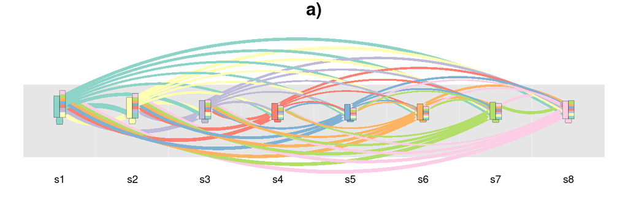

```r
title("a)")
text(1:8, rep(0.2, 8), site, cex = 0.7)
```

```r
# dev.off()
```

## 1.2 Toy example 2

```r
o1 = st_polygon(list(rbind(c(0.5, 0.5), c(1.5, 0.5),
                           c(1.5, 1.5), c(0.5, 1.5), c(0.5, 0.5))))
o2 = o1 + c(1, 0)
o3 = o1 + c(2, 0)
o4 = o1 + c(3, 0)
od1 = o1 + c(1.5, -1)
d1 = o1 + c(0.75, -2)
d2 = o1 + c(2.25, -2)

my_poly_2 = st_sfc(o1, o2, o3, o4, od1, d1, d2)

# give row names to the SPATIAL UNITS
site_o <- c("o1", "o2", "o3", "o4", "od1")
site_d <- c("d1", "d2", "od1")
site_2 <- union(site_o, site_d)
my_poly_2 <-  st_sf(data.frame(name = site_2, geom = my_poly_2))

# construct the centroid coordinates
centro_xy_2 <- st_centroid(my_poly_2)
coords_xy_2 <- st_coordinates(centro_xy_2)
rownames(coords_xy_2) <- site_2

index_o_2 <- rep(site_o, each = 3)
index_d_2 <- rep(site_d, times = 5)
n_o <- 5
n_d <- 3
N_2 <- n_o * n_d
```

We generate the spatial weight matrices at the site level:

```r
# spatial weigh matrices
ow <- matrix(c(0, 1, 0, 0, 0,
               1/2, 0, 0, 0, 1/2,
               0, 0, 0, 1/2, 1/2,
               0, 0, 1, 0, 0,
               0, 1/2, 1/2, 0, 0),
                n_o, n_o, byrow = T)
dimnames(ow) <- list(site_o, site_o)
dw <- matrix(c(0, 0, 1,
               0, 0, 1,
               0.5, 0.5, 0),
                n_d, n_d, byrow = T)
dimnames(dw) <- list(site_d, site_d)
```

We generate the spatial weight matrices at the flow level:

```r
W_d_2 <- kronecker(diag(n_o), dw)
W_o_2 <- kronecker(ow, diag(n_d))
W_w_2 <- kronecker(ow, dw)
```

We generate the explanatory variables:

```r
# x matrix
OX <- data.frame(x = c(40, 20, 10, 7, 10))
rownames(OX) <- site_o
DX <- data.frame(x = c(15, 25, 10))
rownames(DX) <- site_d

# beta parameters
beta_i <- 2
beta_o <- 0.5
beta_d <- 1
delta_o <- 0.1
delta_d <- 0.3
```

We simulate the spatial flows:

```r
# Computing the effects :
x_o_2 <- kronecker(as(OX, "matrix"), rep(1, n_d))
x_d_2 <- kronecker(rep(1, n_o), as(DX, "matrix"))
x_i_2 <- x_o_2 * as.numeric(index_o_2 == index_d_2)

g_2 <- st_distance(st_centroid(my_poly_2))
dimnames(g_2) <- list(site_2, site_2)
g_2 <- g_2[site_o, site_d]

g_2 <- as.vector(t(g_2))
g_2 <- ifelse(g_2 != 0, log(g_2), 0)

Y_full_2 <- solve(diag(N_2) - rho_o * W_o_2 - rho_d * W_d_2 - rho_w * W_w_2,
      x_o_2 * beta_o + x_d_2 * beta_d + x_i_2 * beta_i +
        as.numeric(W_o_2 %*% x_o_2) * delta_o +
        as.numeric(W_d_2 %*% x_d_2) * delta_d + gamma_od * g_2)
```

We represent the flows (Figure 1 b in the article):

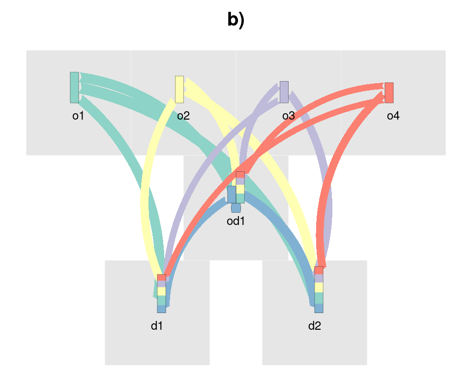

```r
my_col <- RColorBrewer::brewer.pal(7, "Set3")
names(my_col) <- site_2
# pdf("figures/toy_data_2.pdf", width = 5, height = 4)
par(oma = c(0, 0, 0, 0), mar = c(0, 0, 2, 0))
plot_flows(
    as.numeric(Y_full_2), # value of the flow
    index_o_2, # label of the origin
    index_d_2,  # label of the destination
    width_arc = 1.5, # width of the arc that is also equals to the height of the bar
    geo_site = my_poly_2,  # the geographic coordinates of the sites: polygon or points of class sf
    col_site = my_col,
    column_name = "name", # the column name of the regions in geo_site sf object and/or in xy_sf
    add = F,   # if add = T, the arcs and only the arcs will printed on the existing device
    type = "barchart",
    width_bar = 2,
    size_head_arc = 0.5, # the size of the ending and starting of the arrows
    reduce_arc = 0.1, # the percentage of reduction of the flow
    transparency = list(alpha = c(1, 1, 1),    # gives the transparency with respect to the values
                        range = c(60, 87, 120)),
    col_geometry = rgb(0.9, 0.9, 0.9),  # color inside the polygons
    print_names = T,
    size_names = 0.75
)
title("b)")
```

```r
# dev.off()
```

## 1.3 Toy example 3

```r
od1_nc = st_polygon(list(rbind(c(0.5, 0.5), c(1.5, 0.5),
                           c(1.5, 1.5), c(0.5, 1.5), c(0.5, 0.5))))
d1_nc = od1_nc + c(-1.5, 1.5)
d2_nc = od1_nc + c(1.5, 1.5)
d3_nc = od1_nc + c(-1.5, -1.5)
d4_nc = od1_nc + c(1.5, -1.5)

o1_nc = od1_nc + c(-4, 0)
o2_nc = od1_nc + c(0, 4)
o3_nc = od1_nc + c(0, -4)
o4_nc = od1_nc + c(4, 0)

my_poly_nc = st_sfc(o1_nc, o2_nc, o3_nc, o4_nc, od1_nc, d1_nc, d2_nc, d3_nc, d4_nc)

# give row names to the coordinates
site_o_nc <- c("o1", "o2", "o3", "o4", "od1")
site_d_nc <- c("d1", "d2", "d3", "d4", "od1")
site_nc <- union(site_o_nc, site_d_nc)

my_poly_nc <-  st_sf(data.frame(name = site_nc, geom = my_poly_nc))
```

```r
# construct the centroid coordinates
centro_xy_nc <- st_centroid(my_poly_nc)
coords_xy_nc <- st_coordinates(centro_xy_nc)
rownames(coords_xy_nc) <- site_nc

coords_xy_nc <- st_coordinates(st_centroid(my_poly_nc))

n_o_nc <- 5
n_d_nc <- 5

# we generate the full flows
index_o_nc <- rep(site_o_nc, each = n_d_nc)
index_d_nc <- rep(site_d_nc, times = n_o_nc)

# we drop the missing flows
index_missing <- c(2, 4, 8, 9, 11, 12, 16, 18)

# size of the flows
index_o_nc <- index_o_nc[-index_missing]
index_d_nc <- index_d_nc[-index_missing]

N_nc <- length(index_d_nc)
```

We generate the spatial weight matrices at the site level:

```r
# spatial weigh matrices
ow_nc <- matrix(c(0, 1/3, 1/3, 0, 1/3,
               1/3, 0, 0, 1/3, 1/3,
               1/3, 0, 0, 1/3, 1/3,
               0, 1/3, 1/3, 0, 1/3,
               1/4, 1/4, 1/4, 1/4, 0),
                n_o_nc, n_o_nc, byrow = T)
dimnames(ow_nc) <- list(site_o_nc, site_o_nc)
dw_nc <- matrix(c(0, 1/3, 1/3, 0, 1/3,
               1/3, 0, 0, 1/3, 1/3,
               1/3, 0, 0, 1/3, 1/3,
               0, 1/3, 1/3, 0, 1/3,
               1/4, 1/4, 1/4, 1/4, 0),
                n_d_nc, n_d_nc, byrow = T)
dimnames(dw_nc) <- list(site_d_nc, site_d_nc)
```

We generate the spatial weight matrices at the flow level:

```r
W_d_nc <- kronecker(diag(n_o_nc), dw_nc)
W_d_nc <- W_d_nc[-index_missing, -index_missing]
W_o_nc <- kronecker(ow_nc, diag(n_d_nc))
W_o_nc <- W_o_nc[-index_missing, -index_missing]
W_w_nc <- kronecker(ow_nc, dw_nc)
W_w_nc <- W_w_nc[-index_missing, -index_missing]
```

We generate the explanatory variable:

```r
# x matrix
OX_nc <- data.frame(x = c(40, 20, 10, 7, 10))
rownames(OX_nc) <- site_o_nc
DX_nc <- data.frame(x = c(15, 25, 25, 15, 10))
rownames(DX_nc) <- site_d_nc

# beta parameters
beta_i <- 2
beta_o <- 0.5
beta_d <- 1
delta_o <- 0.1
delta_d <- 0.3
```

We simulate the spatial flows:

```r
# Computing the effects :
x_o_nc <- OX_nc[index_o_nc, ]
x_d_nc <- DX_nc[index_d_nc, ]
x_i_nc <- x_o_nc * as.numeric(index_o_nc == index_d_nc)

g_nc <- st_distance(st_centroid(my_poly_nc))
dimnames(g_nc) <- list(site_nc, site_nc)
g_nc <- g_nc[cbind(index_o_nc, index_d_nc)]

g_nc <- as.vector(t(g_nc))
g_nc <- ifelse(g_nc != 0, log(g_nc), 0)

Y_full_nc <- solve(diag(N_nc) - rho_o * W_o_nc - rho_d * W_d_nc - rho_w * W_w_nc,
      x_o_nc * beta_o + x_d_nc * beta_d + x_i_nc * beta_i +
        as.numeric(W_o_nc %*% x_o_nc) * delta_o +
        as.numeric(W_d_nc %*% x_d_nc) * delta_d + gamma_od * g_nc)
```

We represent the flows (Figure 1 c in the article):

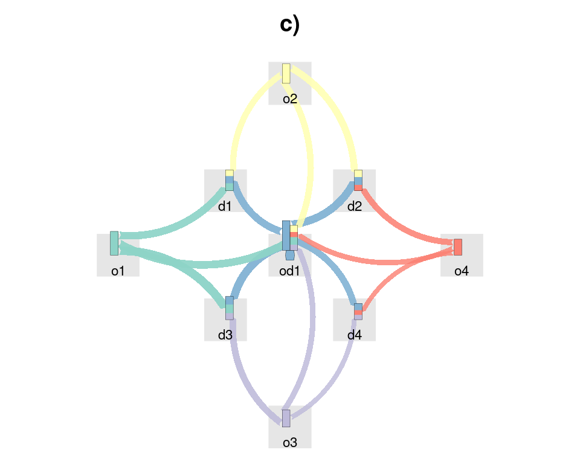

```r
my_col <- RColorBrewer::brewer.pal(9, "Set3")
names(my_col) <- site_nc
# pdf("figures/toy_data_3.pdf", width = 5, height = 4)
par(oma = c(0, 0, 0, 0), mar = c(0, 0, 2, 0))
plot_flows(
    as.numeric(Y_full_nc), # value of the flow
    index_o_nc, # label of the origin
    index_d_nc,  # label of the destination
    width_arc = 1.5, # width of the arc that is also equals to the height of the bar
    width_bar = 2,
    geo_site = my_poly_nc,  # the geographic coordinates of the sites: polygon or points of class sf
    col_site = my_col,
    column_name = "name", # the column name of the regions in geo_site sf object and/or in xy_sf
    add = F,   # if add = T, the arcs and only the arcs will printed on the existing device
    type = "barchart",
    size_head_arc = 0.5, # the size of the ending and starting of the arrows
    reduce_arc = 0.1, # the percentage of reduction of the flow
    transparency = list(alpha = c(0.8, 0.9, 1),    # gives the transparency with respect to the values
                        range = c(40, 60, 86)),
    col_geometry = rgb(0.9, 0.9, 0.9),  # color inside the polygons
    print_names = T,
    size_names = 0.7
)
title("c)")
```

```r
# dev.off()
```

# 2 Our functions

## 2.1 Prediction: cartesian case (no log)

The function `predict_gsim()` allows to compute formulas (18) and (19) in the cartesian case. It requires only the values of the (estimated) parameters, the spatial weight matrices $OW$ ($n_o\times n_o$) and $DW$ ($n_d\times n_d$) and the indexes of the flows at origin and destination. Comparing to the previous function, it also requires the matrices of observations $OX$ and $DX$

```r
source("codes/predict_cartesian.R")
source("codes/predict_non_cartesian.R")
```

In the cartesian case:

```r
predict_gsim(Z, rho, alpha = 0, omega_vec = rep(0, length(ind_o)),
             OW, DW, OX, DX,
             ind_o, ind_d)
```

In the non cartesian case:

```r
predict_gsim_nc(Z, rho, alpha = 0, omega_vec = rep(0, length(ind_o)),
                W_o, W_d, W_w, OX, DX,
                ind_o, ind_d)
```

**Input arguments:**

- `Z`: a `data.frame` of size $p\times 5$, with $p$ being the number of variables. The 5 column names must be `beta_o`, `beta_d`, `beta_i`, `delta_o`, `delta_d`, they correspond to the values of the coefficients in model (2) or (3). Names of the variables are given as `row.names`
- `rho`: a vector of size 3 with the values of `rho_o`, `rho_d`, `rho_w`
- `alpha`: value of the intercept in model (2) or (3)
- `omega_vec`: vector with the values of $G\times\omega$ (can be extended to more variables). Equals 0 by default
- `OW`, `DW`: spatial weight matrices of size $n_o$ and $n_d$
- `OX`, `DX`: the characteristic at the origin and destination sites
- `ind_o`, `ind_d`: indexes of the flows

**Output arguments:** It returns a `vector` of size $N$ with the prediction $TC$

### 2.1.1 Example of use

In the square case:

```r
coeff_x <- data.frame(row.names = "x", beta_o = 0.5, beta_d = 1, beta_i = 2,
                      delta_o = 0.1, delta_d = 0.3)
coeff_x_no_beta_i <- data.frame(row.names = "x", beta_o = 0.5, beta_d = 1, beta_i = 0,
                                delta_o = 0.1, delta_d = 0.3)
# cartesian case
pred_sq <- predict_gsim(coeff_x, rho, alpha = alpha, omega_vec = gamma_od * g,
                          OW = w, DW = w, OX = X, DX = X,
                          ind_o = index_o, ind_d = index_d)
# non cartesian case
pred_sq_2 <- predict_gsim_nc(coeff_x, rho, alpha = alpha,
                             omega_vec = gamma_od * g,
                             W_o, W_d, W_w, OX = X, DX = X,
                          ind_o = index_o, ind_d = index_d)

# comparison
head(cbind(pred_sq, pred_sq_2))
```

```
## 6 x 2 Matrix of class "dgeMatrix"
##        pred_sq
## [1,] 291.75114 291.75114
## [2,] 216.48074 216.48074
## [3,] 147.80494 147.80494
## [4,] 107.50372 107.50372
## [5,]  93.17129  93.17129
## [6,]  98.66383  98.66383
```

Rectangular case:

```r
# cartesian case
pred_rec <- predict_gsim(coeff_x, rho, alpha = alpha, omega_vec = gamma_od * g_2,
                          OW = ow, DW = dw, OX = OX, DX = DX,
                          ind_o = index_o_2, ind_d = index_d_2)
# non cartesian case
pred_rec_2 <- predict_gsim_nc(coeff_x, rho, alpha = alpha,
                             omega_vec = gamma_od * g_2,
                             W_o = W_o_2, W_d = W_d_2, W_w = W_w_2,
                             OX = OX, DX = DX,
                          ind_o = index_o_2, ind_d = index_d_2)

# comparison
head(cbind(pred_rec, pred_rec_2))
```

```
## 6 x 2 Matrix of class "dgeMatrix"
##       pred_rec
## [1,] 103.54946 103.54946
## [2,] 119.99548 119.99548
## [3,] 105.05431 105.05431
## [4,]  89.56133  89.56133
## [5,] 106.10531 106.10531
## [6,]  93.23330  93.23330
```

### 2.1.2 Computation time

We examine the computation time using our algorithm and comparing model (2) and model (3)

```r
# vary the size of n
vec_n <- seq(5, 60, by = 5)
```

```r
time_n <- matrix(0, length(vec_n), 4)
for(k in 1:length(vec_n)) {
  print(k)
  n <- vec_n[k]
  N <- n ^ 2
  w <- matrix(0, n, n, byrow = T)
  site <- paste0("s", 1:n)
  dimnames(w) <- list(site, site)
  for(i in 2:(n-1)) {
    w[i, i-1] <- 0.5
    w[i, i+1] <- 0.5
  }
  w[1, 2] <- 1
  w[n, n-1] <- 1

  index_o <- paste0("s", rep(1:n, each = n))
  index_d <- paste0("s", rep(1:n, times = n))

  X <- data.frame(x = rbinom(n, 100, 0.5))
  rownames(X) <- site

  long <- 1:n
  lat <- rep(1, n)
  g <- as.vector(as.matrix(log(dist(cbind(long, lat)))))
  require("Matrix")
  res <- microbenchmark::microbenchmark(
    temps_1 = {predict_gsim(coeff_x_no_beta_i, rho, alpha = alpha,
                          OW = w, DW = w, OX = X, DX = X,
                          ind_o = index_o, ind_d = index_d)},
    temps_2 = {predict_gsim(coeff_x, rho, alpha = alpha,
                          OW = w, DW = w, OX = X, DX = X,
                          ind_o = index_o, ind_d = index_d)},
    temps_3 = {predict_gsim(coeff_x, rho, alpha = alpha, omega_vec = gamma_od * g,
                          OW = w, DW = w, OX = X, DX = X,
                          ind_o = index_o, ind_d = index_d)},
    temps_4 = {
      W_d <- kronecker(diag(n), w)
      W_o <- kronecker(w, diag(n))
      W_w <- kronecker(w, w)
      x_o <- kronecker(as(X, "matrix"), rep(1, n))
      x_d <- kronecker(rep(1, n), as(X, "matrix"))

      predict_gsim_nc(coeff_x, rho, alpha = alpha,
                             omega_vec = gamma_od * g,
                             W_o = W_o, W_d = W_d, W_w = W_w,
                             OX = X, DX = X,
                          ind_o = index_o, ind_d = index_d)},
    times = 5, unit = "milliseconds"
)
  time_n[k, ] <- summary(res)$mean
}
save(time_n, file = "comp_pred.RData")
```

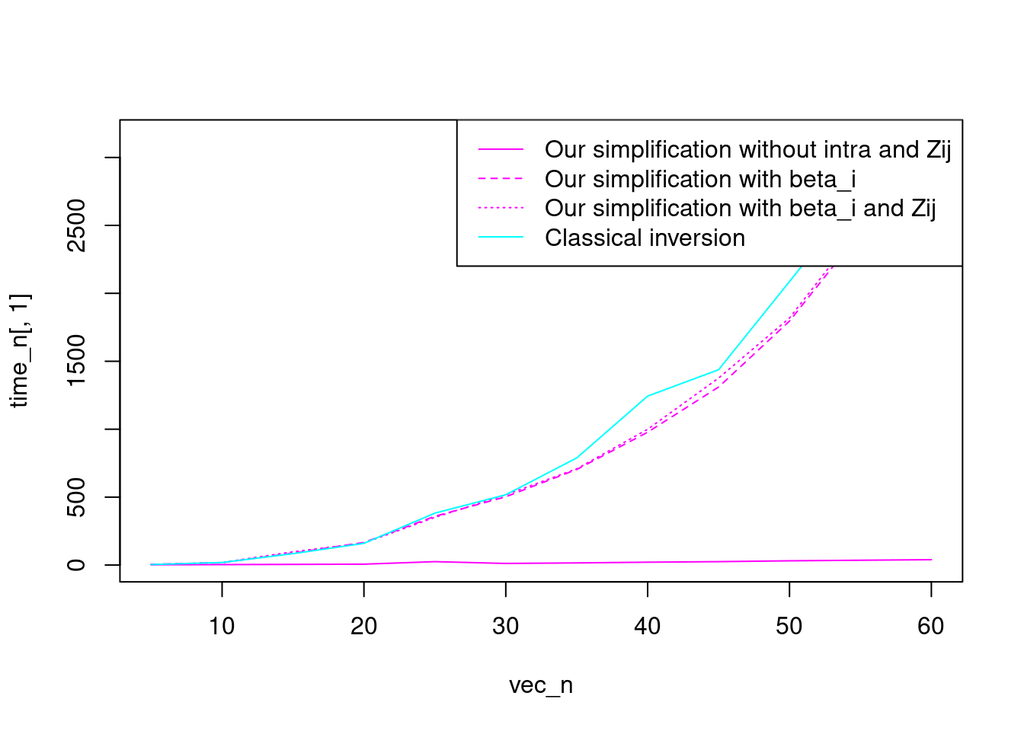

```r
load("comp_pred.RData")
plot(vec_n, time_n[, 1], type = "l", ylim = range(time_n),
     col = "magenta")
lines(vec_n, time_n[, 2], lty = 2, col = "magenta")
lines(vec_n, time_n[, 3], lty = 3, col = "magenta")
lines(vec_n, time_n[, 4], lty = 1, col = "cyan")
legend("topright", legend = c("Our simplification without intra and Zij",
                              "Our simplification with beta_i",
                              "Our simplification with beta_i and Zij",
                              "Classical inversion"),
       lty = c(1, 2, 3, 1, 2), col = c("magenta", "magenta","magenta", "cyan", "cyan"))
```

## 2.2 Impact computation (aggregated by site)

```r
source("codes/compute_effects_cartesian.R")
source("codes/compute_effects_non_cartesian.R")
```

The function `compute_effect()` allows to compute formulas (14) and (15) in the cartesian case. It requires only the values of the (estimated) parameters, the spatial weight matrices $OW$ ($n_o\times n_o$) and $DW$ ($n_d\times n_d$) and the indexes of the flows at origin and destination.

The function `compute_effect_non_cartesian()` requires the spatial weight matrices $W_o$, $W_d$ and $W_w$ ($N\times N$).

```r
compute_effect(Z, rho, OW, DW, ind_o, ind_d, change_z = NULL,
               site = "all", Y_in_log = F, hat_y = NULL)
compute_effect_nc(Z, rho, W_o, W_d, W_w,
               ind_o, ind_d, change_z = 1)
```

**Input arguments:**

- `Z`: a `data.frame` of size $p\times 5$, with $p$ being the number of variables. The 5 column names must be `beta_o`, `beta_d`, `beta_i`, `delta_o`, `delta_d`, they correspond to the values of the coefficients in model (2) or (3). Names of the variables are given as `row.names`
- `rho`: a vector of size 3 with the values of `rho_o`, `rho_d`, `rho_w`
- `OW`, `DW`: spatial weight matrices of size $n_o$ and $n_d$
- `W_o`, `W_d`, `W_w`: spatial weight matrices of size $n_o$ and $n_d$
- `ind_o`, `ind_d`: indexes of the flows
- `change_z`: a numeric equals to 1 by default, it corresponds to the value of the change operated on $\textbf{Z}$
- `site`: a character equals to `"all"` by default; otherwise, the vector indicates the names of the sites to print.
- `Y_in_log = F`, a logical, indicates if the model is in logarithm
- `hat_y = NULL`, a vector of size $N$, if `Y_in_log = T`.

**Output arguments:**

It returns a `list` of size $p$ where each element is a list with two elements:

- `local_effect`: a `matrix` of size $n_S\times 5$ with the impact decomposition for each site
- `n_effect`: a `matrix` of size $n_S\times5$ with the number of elements concerned by a change of $\mathbf{Z}$ on site $s$

### 2.2.1 Example of use

In the first toy example:

```r
#### Square case
# cartesian case
sq <- compute_effect(coeff_x, rho, OW = w, DW = w, ind_o = index_o, ind_d = index_d)
sq_x <- sq$x
# non cartesian case
sq_nc <- compute_effect_nc(coeff_x, rho, W_o = W_o,  W_d = W_d, W_w = W_w,
                             ind_o = index_o, ind_d = index_d)
sq_x_nc <- sq_nc$x

#### Rectangular case
# cartesian case
rec <- compute_effect(coeff_x, rho, OW = ow, DW = dw, ind_o = index_o_2, ind_d = index_d_2)
rec_x <- rec$x
# non cartesian case
rec_nc <- compute_effect_nc(coeff_x, rho, W_o = W_o_2,  W_d = W_d_2, W_w = W_w_2,
                             ind_o = index_o_2, ind_d = index_d_2)
rec_x_nc <- rec_nc$x
```

To get the impact decomposition:

```r
# square case
sq_x$local_effect
```

```
##          IE        OE       DE       NE       TE
## s1 5.260492  8.097852 14.51422  8.56005 36.43261
## s2 5.670478 10.972138 17.16291 23.18877 56.99429
## s3 5.278164  9.819828 15.70425 18.89860 49.70084
## s4 5.261295  9.626737 15.54476 17.82489 48.25768
## s5 5.261295  9.626737 15.54476 17.82489 48.25768
## s6 5.278164  9.819828 15.70425 18.89860 49.70084
## s7 5.670478 10.972138 17.16291 23.18877 56.99429
## s8 5.260492  8.097852 14.51422  8.56005 36.43261
```

```r
# rectangular case
rec_x$local_effect
```

```
##           IE       OE        DE        NE        TE
## o1  0.000000 2.841615  0.000000  1.086957  3.928571
## o2  0.000000 3.020186  0.000000  2.872671  5.892857
## o3  0.000000 3.020186  0.000000  2.872671  5.892857
## o4  0.000000 2.841615  0.000000  1.086957  3.928571
## d1  0.000000 0.000000  9.722222  4.861111 14.583333
## d2  0.000000 0.000000  9.722222  4.861111 14.583333
## od1 5.782313 6.768707 11.309524 14.047619 37.908163
```

To obtain the number of terms:

```r
# square case
sq_x$n_effect
```

```
##    IE OE DE NE TE
## s1  1  7  7 49 64
## s2  1  7  7 49 64
## s3  1  7  7 49 64
## s4  1  7  7 49 64
## s5  1  7  7 49 64
## s6  1  7  7 49 64
## s7  1  7  7 49 64
## s8  1  7  7 49 64
```

```r
# rectangular case
rec_x$n_effect
```

```
##     IE OE DE NE TE
## o1   0  3  0 12 15
## o2   0  3  0 12 15
## o3   0  3  0 12 15
## o4   0  3  0 12 15
## d1   0  0  5 10 15
## d2   0  0  5 10 15
## od1  1  2  4  8 15
```

### 2.2.2 Computation time

We examine the computation time using our algorithm and comparing model (2) and model (3)

```r
# vary the size of n
vec_n <- seq(5, 60, by = 5)
```

```r
time_n <- matrix(0, length(vec_n), 3)
for(k in 1:length(vec_n)) {
  print(k)
  n <- vec_n[k]
  w <- matrix(0, n, n, byrow = T)
  dimnames(w) <- list(paste0("s", 1:n), paste0("s", 1:n))
  for(i in 2:(n-1)) {
    w[i, i-1] <- 0.5
    w[i, i+1] <- 0.5
  }
  w[1, 2] <- 1
  w[n, n-1] <- 1

  index_o <- paste0("s", rep(1:n, each = n))
  index_d <- paste0("s", rep(1:n, times = n))

  res <- microbenchmark::microbenchmark(
    model_2 = {compute_effect(coeff_x, rho, OW = w, DW = w,
                              ind_o = index_o, ind_d = index_d)},
    model_3 = {compute_effect(coeff_x_no_beta_i, rho, OW = w, DW = w,
                              ind_o = index_o, ind_d = index_d)},
    non_car = {
      W_d <- kronecker(diag(n), w)
      W_o <- kronecker(w, diag(n))
      W_w <- kronecker(w, w)
      compute_effect_nc(coeff_x, rho, W_o = W_o,  W_d = W_d, W_w = W_w,
                             ind_o = index_o, ind_d = index_d)
    },
    times = 5)
  time_n[k, ] <- summary(res)$mean
}
save(time_n, file = "comp_1.RData")
```

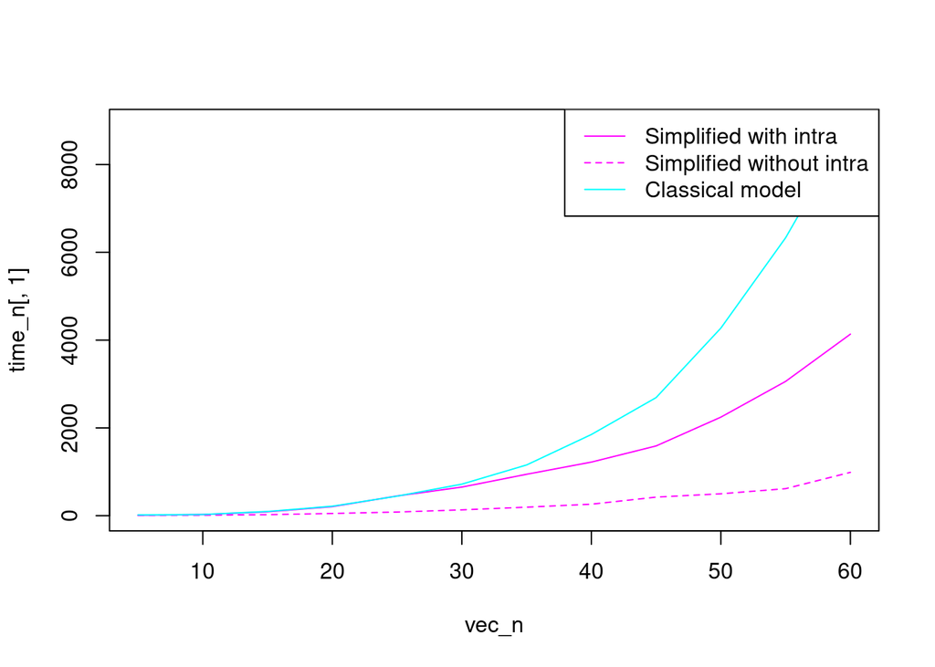

```r
load("comp_1.RData")
plot(vec_n, time_n[, 1], type = "l", ylim = range(time_n), col = "magenta")
lines(vec_n, time_n[, 2], lty = 2, col = "magenta")
lines(vec_n, time_n[, 3], lty = 1, col = "cyan")
legend("topright", legend = c("Simplified with intra",
                              "Simplified without intra",
                              "Classical model"),
       lty = c(1, 2, 1), col = c("magenta", "magenta", "cyan"))
```

### 2.2.3 Model in log

If the dependent variable in the model is in log, one should use the argument `Y_in_log = T` and add the argument `hat_y`

```r
coeff_x_log <- data.frame(row.names = "x", beta_o = 0.05, beta_d = 0.1, beta_i = 0.01,
                      delta_o = 0.02, delta_d = 0.05)

pred_sq_log <- exp(predict_gsim(coeff_x_log, rho, alpha = 0, omega_vec = gamma_od * g,
                          OW = w, DW = w, OX = X, DX = X,
                          ind_o = index_o, ind_d = index_d))

sq_log <- compute_effect(coeff_x_log, rho, OW = w, DW = w,
                         ind_o = index_o, ind_d = index_d,
                         Y_in_log = T, hat_y = pred_sq_log)
```

Comparison of computation time:

```r
microbenchmark::microbenchmark(
  no_log = {compute_effect(coeff_x, rho, OW = w, DW = w,
                         ind_o = index_o, ind_d = index_d)},
  log = {compute_effect(coeff_x, rho, OW = w, DW = w,
                         ind_o = index_o, ind_d = index_d,
                         Y_in_log = T, hat_y = rep(1, N))},
  times = 5
)
```

```
## Unit: milliseconds
##    expr      min       lq     mean   median       uq      max neval
##  no_log 5.641363 5.748671 5.927912 5.776708 5.785332 6.687488     5
##     log 4.454967 4.495966 4.631331 4.568221 4.623096 5.014404     5
```

### 2.2.4 Alternative way returning all impacts

The functions `compute_all_effect()` and `compute_all_effect_nc()` return all elements in formula (11) for any $s\in S$, $Z$, and pair $o:d$. Decomposition is done according to formula (7).

```r
source("codes/compute_all_effects_cartesian.R")
source("codes/compute_all_effects_non_cartesian.R")
```

**Usage:**

```r
compute_all_effect(Z, rho, OW, DW, ind_o, ind_d, change_z = NULL,
                               site = "all", Y_in_log = F, hat_y = NULL)
compute_all_effect_nc(Z, rho, W_o, W_d, W_w,
                                  ind_o, ind_d, change_z = NULL,
                                  site = "all", Y_in_log = F, hat_y = NULL)
```

**Input arguments:** same as previous

**Output argument:** a `data.frame` with 4 columns `site`, `type`, `var`, `values`.

# 3 Model interpretation

## 3.1 Toy data 1

Considering Model (3) with intra effect, we use function `compute_effect()` to get the decomposition of the impacts:

To get the scalar measures’ summary (as presented in Table 1):

```r
kableExtra::kable(apply(sq_x$local_effect, 2, sum) / N)
```

|  | x |
| --- | --- |
| IE | 0.6709509 |
| OE | 1.2036423 |
| DE | 1.9664414 |
| NE | 2.1397598 |
| TE | 5.9807945 |

We transform the data in a long format:

```r
local_effect <- data.frame(sq_x$local_effect)
local_effect$site <- row.names(local_effect)
local_effect <- pivot_longer(local_effect, cols = 1:5,
                             names_to = "type",
                             values_to = "values")
```

To obtain Figure 2 a) in the article,

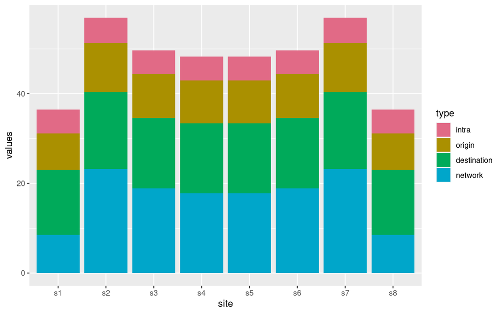

```r
q4 <- colorspace::qualitative_hcl(5, palette = "Dark 3")
local_effect$type <- factor(local_effect$type,
      levels = c("IE", "OE", "DE", "NE", "TE"),
      labels = c("intra", "origin", "destination", "network", "total"))
local_effect %>%
  filter(type != "total") %>%
  ggplot() +
  geom_col(aes(x = site, fill = type, y = values))  +
  scale_fill_manual(values = q4[1:4])
```

```r
# ggsave( filename = "./figures/barplot.pdf", width = 8, height = 5)
```

We compute the share by site:

```r
time_chart <- local_effect %>%
    filter(type != "total") %>%
  group_by(site, type) %>%
  summarise(impacts = sum(values)) %>%
  group_by(site) %>%
  summarise(
    type = type,
    impacts = impacts / sum(impacts))
```

To obtain Figure 2 b) in the article,

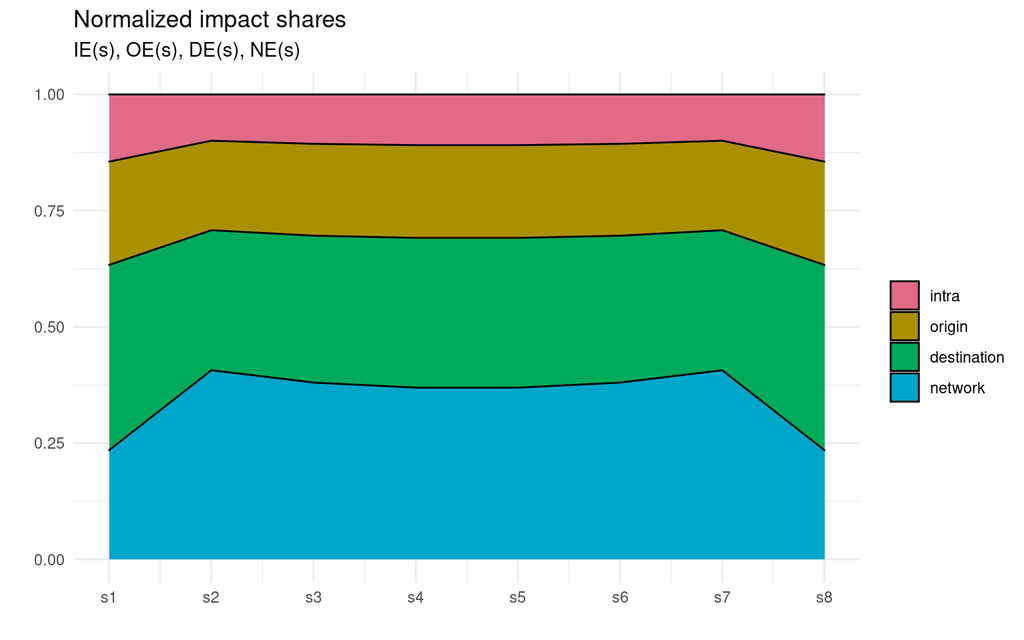

```r
# we normalize
ggplot(time_chart,
  aes(x = as.numeric(substr(site, 2, 2)),
      y = impacts,
      fill = factor(type, levels = c("intra", "origin", "destination", "network") ))) +
  geom_area(color = "black") +
  scale_fill_manual(values = q4[1:4]) +
  labs(title = "Normalized impact shares",
       subtitle = "IE(s), OE(s), DE(s), NE(s)",
       x = "",
       y = "",
       fill = "")  +
  theme_minimal() +
  scale_x_continuous(breaks = 1:8,
                     labels = c(paste0("s", 1:8)))
```

```r
# ggsave( filename = "./figures/shareplot.pdf", width = 8, height = 5)
```

To obtain local average effects as proposed in Table 3:

```r
sq_x$local_effect / sq_x$n_effect
```

```
##          IE       OE       DE        NE        TE
## s1 5.260492 1.156836 2.073459 0.1746949 0.5692595
## s2 5.670478 1.567448 2.451844 0.4732401 0.8905358
## s3 5.278164 1.402833 2.243464 0.3856858 0.7765757
## s4 5.261295 1.375248 2.220679 0.3637734 0.7540263
## s5 5.261295 1.375248 2.220679 0.3637734 0.7540263
## s6 5.278164 1.402833 2.243464 0.3856858 0.7765757
## s7 5.670478 1.567448 2.451844 0.4732401 0.8905358
## s8 5.260492 1.156836 2.073459 0.1746949 0.5692595
```

We use function `compute_all_effect()` to obtain all the individual impacts:

```r
my_data_vis_total <- compute_all_effect(coeff_x, rho, OW = w, DW = w,
                              ind_o = index_o, ind_d = index_d)
```

We add a level “total” to our data:

```r
my_data_vis_total <- rbind(my_data_vis_total,
                           data.frame(site = my_data_vis_total$site,
                                      var = "x", type = "total",
                                      values = my_data_vis_total$values))
my_data_vis_total$type <- factor(my_data_vis_total$type,
                          levels = c("intra", "origin", "destination", "network", "total"))
# we add all the sites
my_data_vis_total <- rbind(my_data_vis_total,
                           data.frame(site = "all sites",
                                      var = my_data_vis_total$var,
                                      type = my_data_vis_total$type,
                                      values = my_data_vis_total$values))
```

To get Figure 3 in the article:

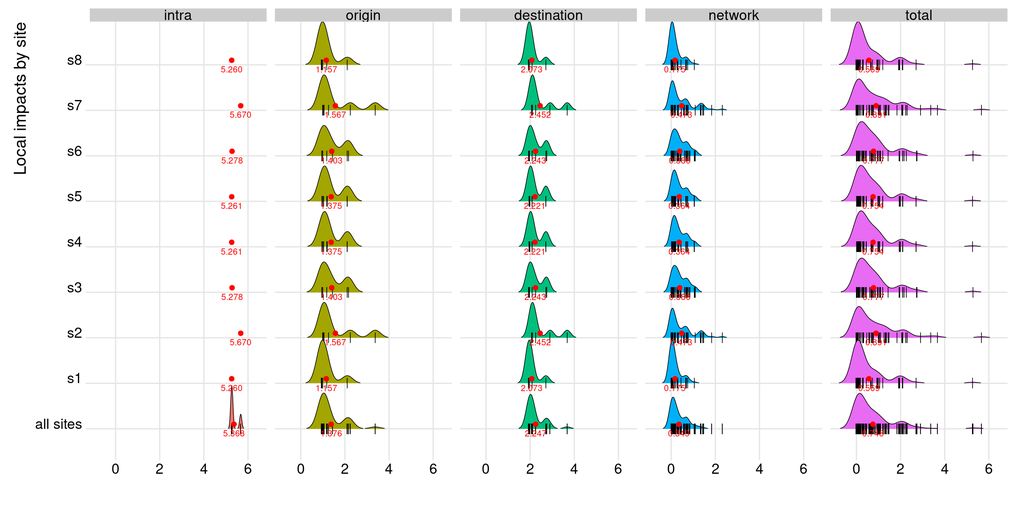

## 3.2 Toy data 2

We use function `compute_effect()` to get the impact decomposition:

To obtain the scalar summary measures:

```r
kableExtra::kable(apply(rec$x$local_effect, 2, sum) / N_2)
```

|  | x |
| --- | --- |
| IE | 0.3854875 |
| OE | 1.2328207 |
| DE | 2.0502646 |
| NE | 2.1126064 |
| TE | 5.7811791 |

To obtain Table 2, we change the parameter `type_x`:

```r
kableExtra::kable(rec$x$n_effect)
```

|  | IE | OE | DE | NE | TE |
| --- | --- | --- | --- | --- | --- |
| o1 | 0 | 3 | 0 | 12 | 15 |
| o2 | 0 | 3 | 0 | 12 | 15 |
| o3 | 0 | 3 | 0 | 12 | 15 |
| o4 | 0 | 3 | 0 | 12 | 15 |
| d1 | 0 | 0 | 5 | 10 | 15 |
| d2 | 0 | 0 | 5 | 10 | 15 |
| od1 | 1 | 2 | 4 | 8 | 15 |

To obtain Figure 4 in the article, we first need to transform the data in a long format:

```r
local_effect_2 <- data.frame(rec$x$local_effect)
local_effect_2$site <- row.names(local_effect_2)
local_effect_2 <- pivot_longer(local_effect_2, cols = 1:5,
                             names_to = "type",
                             values_to = "values")
```

To obtain Figure 4:

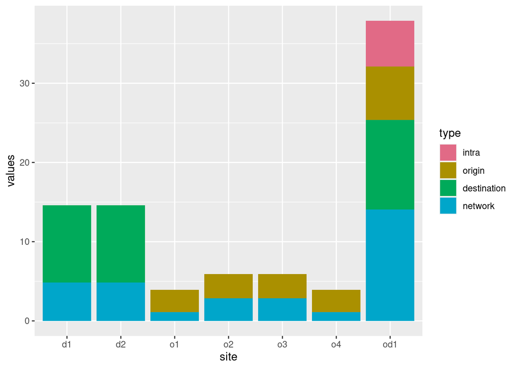

```r
local_effect_2$type <- factor(local_effect_2$type,
      levels = c("IE", "OE", "DE", "NE", "TE"),
      labels = c("intra", "origin", "destination", "network", "total"))
local_effect_2 %>%
  filter(type != "total") %>%
  ggplot() +
  geom_col(aes(x = site, fill = type, y = values)) +
  scale_fill_manual(values = q4[1:4])
```

```r
# ggsave( filename = "./figures/barplot_2.pdf", width = 8, height = 5)
```

To obtain Figure 5 in the article, we use the function `compute_all_effect()`

```r
my_data_vis_total <- compute_all_effect(coeff_x, rho, OW = ow, DW = dw,
                                ind_o = index_o_2, ind_d = index_d_2)
```

```r
my_data_vis_total <- data.frame(my_data_vis_total)
# we add the total impacts
my_data_vis_total <- rbind(my_data_vis_total,
                           data.frame(site = my_data_vis_total$site,
                                      var = my_data_vis_total$var,
                                      type = "total",
                                      values = my_data_vis_total$values))
my_data_vis_total$type <- factor(my_data_vis_total$type,
                          levels = c("intra", "origin", "destination", "network", "total"))
# we add all the sites
my_data_vis_total <- rbind(my_data_vis_total,
                           data.frame(site = "all sites",
                                      var = my_data_vis_total$var,
                                      type = my_data_vis_total$type,
                                      values = my_data_vis_total$values))
```

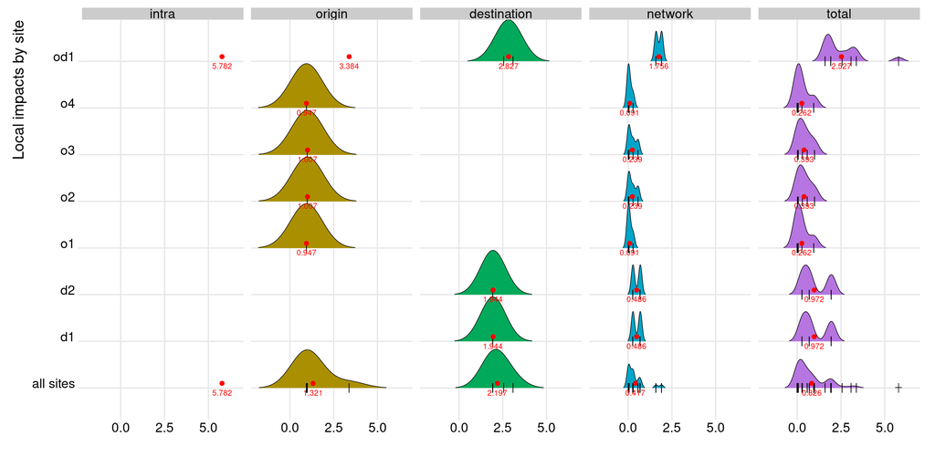

# 4 Case study (model in log)

```r
load("data/remit_macro.RData")
```

## 4.1 Map flows

To obtain Figure 6 in the article :

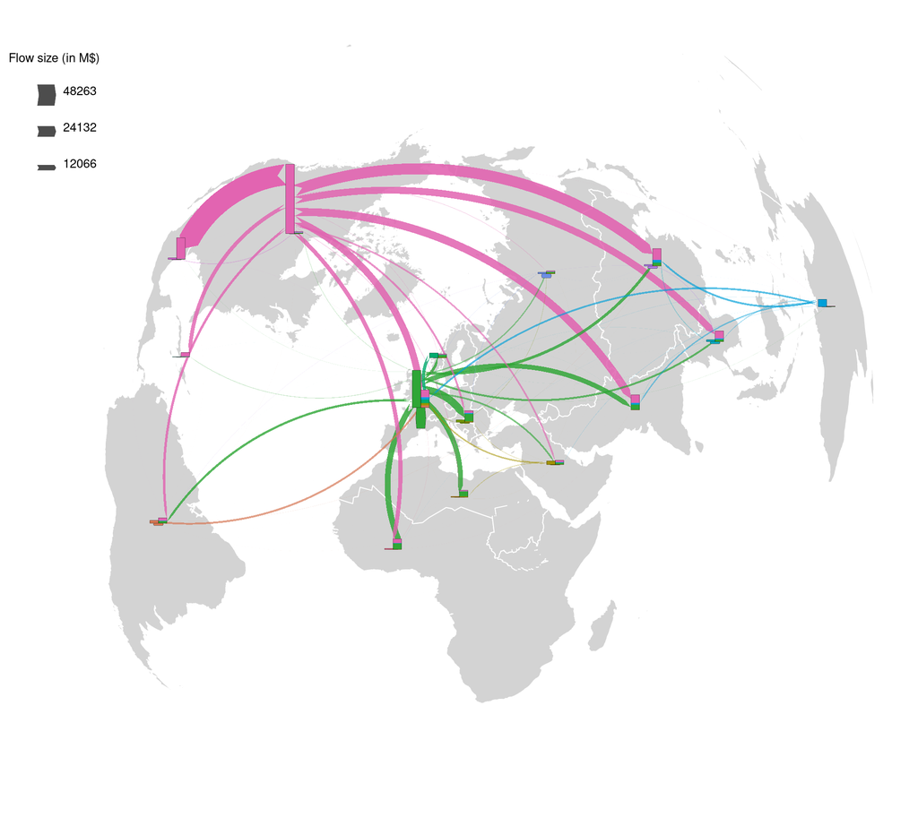

```r
library(sf)
y <- pairs_od$y
index_o <- as.character(pairs_od$cont_o)
index_d <- as.character(pairs_od$cont_d)
# pdf("figures/remit_1.pdf", width = 10, height = 8)
par(oma = c(0, 0, 0, 0), mar = c(0, 0, 1, 0)) # , bg = "#AFEEEE")
plot(st_geometry(region_sf),  ylim = c(-5000000, 10000000),
    col = "lightgrey",  # color inside the polygons
    border = "white")
plot_flows(
    y, # value of the flow
    index_o, # label of the origin
    index_d,  # label of the destination
    geo_site = region_sf,  # the geographic coordinates of the sites: polygon or points of class sf
    column_name = "region", # the column name of the regions in geo_site sf object and/or in xy_sf
    add = T,   # if add = T, the arcs and only the arcs will printed on the existing device
    type = "barchart", # if T plot barplot for outloflows/inflows and intra flows
    xy_sf = my_centro,
    transparency = list(alpha = c(0, 0.8, 1),
                        range = c(0, 5000, 50000)),
    print_legend = T,
    pos_legend = "topleft",
    size_legend = 0.8,
    title_legend = "Flow size (in M$)"
    )
```

```r
dev.off()
```

We define `OW_remit` and `DW_remit` as the spatial weight matrices of the origins, resp. destinations based on 3 nearest neighbours

```r
n_o_remit <- nrow(OX_remit)
names_o <- levels(OX_remit$cont)
names_o <- names_o[names_o != "S.Asia"]
OW_remit <- matrix(0, n_o_remit, n_o_remit)
dimnames(OW_remit) <- list(names_o, names_o)
OW_remit["Africa", c("N.Africa", "UE-bef-2004", "M.East")] <- 1/3
OW_remit["C.America", c("N.America", "S.America", "Caribbean")] <- 1/3
OW_remit["Caribbean", c("C.America", "N.America", "S.America")] <- 1/3
OW_remit["E.Asia", c("SE.Asia", "ex-URSS", "Pacific")] <- 1/3
OW_remit["Eu-oth", c("UE-bef-2004", "UE-aft-2004", "ex-URSS")] <- 1/3
OW_remit["ex-URSS", c("E.Asia", "M.East", "UE-aft-2004")] <- 1/3
OW_remit["M.East", c("N.Africa", "Africa", "ex-URSS")] <- 1/3
OW_remit["N.Africa", c("Africa", "UE-bef-2004", "M.East")] <- 1/3
OW_remit["N.America", c("C.America", "Caribbean", "UE-bef-2004")] <- 1/3
OW_remit["Pacific", c("SE.Asia", "E.Asia", "S.America")] <- 1/3
OW_remit["S.America", c("N.America", "Caribbean", "C.America")] <- 1/3
OW_remit["SE.Asia", c("Pacific", "E.Asia", "ex-URSS")] <- 1/3
OW_remit["UE-aft-2004", c("UE-bef-2004", "Eu-oth", "ex-URSS")] <- 1/3
OW_remit["UE-bef-2004", c("Eu-oth", "UE-aft-2004", "N.Africa")] <- 1/3
```

```r
n_d_remit <- nrow(DX_remit)
names_d <- levels(DX_remit$cont)
DW_remit <- matrix(0, n_d_remit, n_d_remit)
dimnames(DW_remit) <- list(names_d, names_d)
DW_remit["Africa", c("N.Africa", "UE-bef-2004", "M.East")] <- 1/3
DW_remit["C.America", c("N.America", "S.America", "Caribbean")] <- 1/3
DW_remit["Caribbean", c("C.America", "N.America", "S.America")] <- 1/3
DW_remit["E.Asia", c("SE.Asia", "ex-URSS", "S.Asia")] <- 1/3
DW_remit["Eu-oth", c("UE-bef-2004", "UE-aft-2004", "ex-URSS")] <- 1/3
DW_remit["ex-URSS", c("E.Asia", "M.East", "UE-aft-2004")] <- 1/3
DW_remit["M.East", c("N.Africa", "Africa", "ex-URSS")] <- 1/3
DW_remit["N.Africa", c("Africa", "UE-bef-2004", "M.East")] <- 1/3
DW_remit["N.America", c("C.America", "Caribbean", "UE-bef-2004")] <- 1/3
DW_remit["Pacific", c("SE.Asia", "E.Asia", "S.Asia")] <- 1/3
DW_remit["S.America", c("N.America", "Caribbean", "C.America")] <- 1/3
DW_remit["S.Asia", c("SE.Asia", "E.Asia", "ex-URSS")] <- 1/3
DW_remit["SE.Asia", c("Pacific", "E.Asia", "S.Asia")] <- 1/3
DW_remit["UE-aft-2004", c("UE-bef-2004", "Eu-oth", "ex-URSS")] <- 1/3
DW_remit["UE-bef-2004", c("Eu-oth", "UE-aft-2004", "N.Africa")] <- 1/3
```

## 4.2 Estimation

For estimation, we need to load some functions:

```r
source("codes/ftrace1.R")
source("codes/sar_flow_2.R")
```

Model estimation requires the computation of spatial weight matrices $W_o$ and $W_d$:

```r
W_o_remit <- kronecker(OW_remit, diag(n_d_remit))
flow_names <- paste0(rep(names_o, each = 15), "-", rep(names_d, times = 14))
dimnames(W_o_remit) <- list(flow_names, flow_names)
W_d_remit <- kronecker(diag(n_o_remit), DW_remit)
dimnames(W_d_remit) <- list(flow_names, flow_names)
pairs_od$cont_o <- as.character(pairs_od$cont_o)
pairs_od$cont_d <- as.character(pairs_od$cont_d)
row.names(pairs_od) <- paste0(pairs_od$cont_o, "-", pairs_od$cont_d)
pairs_od <- pairs_od[flow_names, ]
```

We also need to generate the explanatory variables:

```r
row.names(OX_remit) <- OX_remit$cont
row.names(DX_remit) <- DX_remit$cont
my_data_c <- data.frame(
  log_send_electricity_use_pc = OX_remit[pairs_od$cont_o,
                "log_electricity_use_pc"],
  log_sendpop = OX_remit[pairs_od$cont_o, "log_pop"],
  send_WU_resid = OX_remit[pairs_od$cont_o, "WU_resid"],
  lagged_log_send_electricity_use_pc = W_o_remit %*%
    OX_remit[pairs_od$cont_o, "log_electricity_use_pc"],
  log_rec_electricity_use_pc = DX_remit[pairs_od$cont_d,
                                        "log_electricity_use_pc"],
  log_rec_pop = DX_remit[pairs_od$cont_d, "log_pop"],
  rec_polstab = DX_remit[pairs_od$cont_d, "polstab"],
  lagged_log_rec_electricity_use_pc = W_d_remit %*%
    DX_remit[pairs_od$cont_d, "log_electricity_use_pc"],
  log_intra_electricity_use_pc = ifelse(pairs_od$cont_o == pairs_od$cont_d,
      OX_remit[pairs_od$cont_o, "log_electricity_use_pc"], 0),
  log_intra_pop = ifelse(pairs_od$cont_o == pairs_od$cont_d,
      OX_remit[pairs_od$cont_o, "log_pop"], 0),
  cst_intra = ifelse(pairs_od$cont_o == pairs_od$cont_d, 1, 0))
```

We consider first the gravity model or ordinary linear model (OLM) and we print the estimates exhibited in Table 4 of the article:

```r
data_olm <- data.frame(y = log(1 + pairs_od$y),
   my_data_c[, !(names(my_data_c) %in% c("log_intra_electricity_use_pc",
                                            "log_intra_pop", "cst_intra"))],
   g = log(1 + pairs_od$g))

olm <- lm(y ~ log_send_electricity_use_pc + log_rec_electricity_use_pc +
            log_sendpop + send_WU_resid + log_rec_pop +
            rec_polstab + g, data = data_olm)
summary(olm)
```

```
##
## Call:
## lm(formula = y ~ log_send_electricity_use_pc + log_rec_electricity_use_pc +
##     log_sendpop + send_WU_resid + log_rec_pop + rec_polstab +
##     g, data = data_olm)
##
## Residuals:
##     Min      1Q  Median      3Q     Max
## -5.5100 -0.8816 -0.0116  0.9813  4.0897
##
## Coefficients:
##                              Estimate Std. Error t value Pr(>|t|)
## (Intercept)                 -12.07892    3.80322  -3.176  0.00173 **
## log_send_electricity_use_pc   1.85868    0.11049  16.822  < 2e-16 ***
## log_rec_electricity_use_pc    0.26675    0.13560   1.967  0.05053 .
## log_sendpop                   0.52441    0.08480   6.184  3.4e-09 ***
## send_WU_resid                -0.18154    0.03244  -5.596  7.1e-08 ***
## log_rec_pop                   0.88689    0.08631  10.276  < 2e-16 ***
## rec_polstab                   0.55177    0.20703   2.665  0.00832 **
## g                            -1.90848    0.14967 -12.751  < 2e-16 ***
## ---
## Signif. codes:  0 '***' 0.001 '**' 0.01 '*' 0.05 '.' 0.1 ' ' 1
##
## Residual standard error: 1.393 on 202 degrees of freedom
## Multiple R-squared:  0.7173, Adjusted R-squared:  0.7075
## F-statistic: 73.22 on 7 and 202 DF,  p-value: < 2.2e-16
```

Then we add the lagged explanatoty variables to obtain the SLX model:

```r
slx <- lm(y ~ log_send_electricity_use_pc + log_rec_electricity_use_pc +
            lagged_log_send_electricity_use_pc + lagged_log_rec_electricity_use_pc +
            log_sendpop + send_WU_resid + log_rec_pop +
            rec_polstab + g, data = data_olm)
summary(slx)
```

```
##
## Call:
## lm(formula = y ~ log_send_electricity_use_pc + log_rec_electricity_use_pc +
##     lagged_log_send_electricity_use_pc + lagged_log_rec_electricity_use_pc +
##     log_sendpop + send_WU_resid + log_rec_pop + rec_polstab +
##     g, data = data_olm)
##
## Residuals:
##     Min      1Q  Median      3Q     Max
## -5.4336 -0.8340 -0.0156  1.0408  4.1588
##
## Coefficients:
##                                    Estimate Std. Error t value Pr(>|t|)
## (Intercept)                        -5.54449    5.59352  -0.991  0.32277
## log_send_electricity_use_pc         1.86097    0.11040  16.856  < 2e-16 ***
## log_rec_electricity_use_pc          0.18322    0.14488   1.265  0.20746
## lagged_log_send_electricity_use_pc -0.11619    0.23301  -0.499  0.61859
## lagged_log_rec_electricity_use_pc  -0.33338    0.20669  -1.613  0.10833
## log_sendpop                         0.51949    0.08531   6.089 5.71e-09 ***
## send_WU_resid                      -0.18514    0.03245  -5.706 4.12e-08 ***
## log_rec_pop                         0.84622    0.08975   9.429  < 2e-16 ***
## rec_polstab                         0.68517    0.22251   3.079  0.00237 **
## g                                  -1.95726    0.15231 -12.850  < 2e-16 ***
## ---
## Signif. codes:  0 '***' 0.001 '**' 0.01 '*' 0.05 '.' 0.1 ' ' 1
##
## Residual standard error: 1.39 on 200 degrees of freedom
## Multiple R-squared:  0.7213, Adjusted R-squared:  0.7087
## F-statistic: 57.51 on 9 and 200 DF,  p-value: < 2.2e-16
```

To obtain the Moran indexes on the residuals of the OLM and SLX:

```r
library(spdep)
lm.morantest(olm, listw = mat2listw(W_d_remit))
```

```
##
##  Global Moran I for regression residuals
##
## data:
## model: lm(formula = y ~ log_send_electricity_use_pc +
## log_rec_electricity_use_pc + log_sendpop + send_WU_resid + log_rec_pop
## + rec_polstab + g, data = data_olm)
## weights: mat2listw(W_d_remit)
##
## Moran I statistic standard deviate = 5.1608, p-value = 1.229e-07
## alternative hypothesis: greater
## sample estimates:
## Observed Moran I      Expectation         Variance
##      0.252290252     -0.022552291      0.002836158
```

```r
lm.morantest(olm, listw = mat2listw(W_o_remit))
```

```
##
##  Global Moran I for regression residuals
##
## data:
## model: lm(formula = y ~ log_send_electricity_use_pc +
## log_rec_electricity_use_pc + log_sendpop + send_WU_resid + log_rec_pop
## + rec_polstab + g, data = data_olm)
## weights: mat2listw(W_o_remit)
##
## Moran I statistic standard deviate = 1.9768, p-value = 0.02403
## alternative hypothesis: greater
## sample estimates:
## Observed Moran I      Expectation         Variance
##      0.081228992     -0.023826483      0.002824336
```

```r
lm.morantest(slx, listw = mat2listw(W_d_remit))
```

```
##
##  Global Moran I for regression residuals
##
## data:
## model: lm(formula = y ~ log_send_electricity_use_pc +
## log_rec_electricity_use_pc + lagged_log_send_electricity_use_pc +
## lagged_log_rec_electricity_use_pc + log_sendpop + send_WU_resid +
## log_rec_pop + rec_polstab + g, data = data_olm)
## weights: mat2listw(W_d_remit)
##
## Moran I statistic standard deviate = 5.125, p-value = 1.487e-07
## alternative hypothesis: greater
## sample estimates:
## Observed Moran I      Expectation         Variance
##      0.242653055     -0.029043608      0.002810428
```

```r
lm.morantest(slx, listw = mat2listw(W_o_remit))
```

```
##
##  Global Moran I for regression residuals
##
## data:
## model: lm(formula = y ~ log_send_electricity_use_pc +
## log_rec_electricity_use_pc + lagged_log_send_electricity_use_pc +
## lagged_log_rec_electricity_use_pc + log_sendpop + send_WU_resid +
## log_rec_pop + rec_polstab + g, data = data_olm)
## weights: mat2listw(W_o_remit)
##
## Moran I statistic standard deviate = 1.7764, p-value = 0.03783
## alternative hypothesis: greater
## sample estimates:
## Observed Moran I      Expectation         Variance
##      0.064576620     -0.029779891      0.002821415
```

We consider model (2) without intra effect:

```r
set.seed(123)
system.time(sdm_bay_without_intra <- sar_flow_2(
  x = my_data_c[, !(names(my_data_c) %in% c("log_intra_electricity_use_pc",
                     "log_intra_pop", "cst_intra"))],
  y = log(1 + pairs_od$y),
  g = log(1 + pairs_od$g),
  W_o = W_o_remit, W_d = W_d_remit,
  model = "model_7"))

# We consider model (3) with intra effect:
sdm_bay_with_intra <- sar_flow_2(
  x = my_data_c,
  y = log(1 + pairs_od$y),
  g = log(1 + pairs_od$g),
  W_o = W_o_remit, W_d = W_d_remit,
  model = "model_7")
save(sdm_bay_without_intra, sdm_bay_with_intra, file = "result/res_bayes.RData")
```

```r
sdm_bay_sum_with_intra <- summary_bayesian_sar_flow(sdm_bay_with_intra)
```

```
##               mean       median     lower_05    lower_95     t_stat
##  [1,]   0.29453635   0.29271041   0.19386941  0.39509012  4.6926346
##  [2,]   0.11288549   0.11254572  -0.01097374  0.23819877  1.5135738
##  [3,] -17.59167015 -17.74059244 -27.08509814 -8.08134794 -2.9999919
##  [4,]   1.45442003   1.45296098   1.19630954  1.71830541  9.1788746
##  [5,]   0.43177213   0.43273037   0.27813320  0.58075671  4.7145476
##  [6,]  -0.12241157  -0.12281992  -0.17760812 -0.06721744 -3.6059772
##  [7,]  -0.19931545  -0.19383887  -0.58645703  0.18085601 -0.8544092
##  [8,]   0.39917955   0.39707765   0.15158911  0.62946226  2.7919805
##  [9,]   0.85578531   0.85578641   0.68268796  1.03376252  8.0275001
## [10,]   0.45952937   0.46498509   0.10671781  0.81429296  2.1506800
## [11,]  -0.08931158  -0.09133971  -0.41708799  0.23682017 -0.4486148
## [12,]  -1.84266944  -1.84196411  -2.48422871 -1.19379925 -4.6478168
## [13,]  -0.67249543  -0.67320083  -1.21261561 -0.13694496 -2.0520709
## [14,]  30.61717895  30.60041424  16.91623318 43.95680873  3.6949156
## [15,]  -1.20511807  -1.20312551  -1.61197499 -0.82611293 -5.0776233
```

```r
# proba_coeff <- pt(sdm_bay_with_intra[, 4])
```

```r
sdm_bay_sum_without_intra <- summary_bayesian_sar_flow(sdm_bay_without_intra)
```

```
##              mean      median     lower_05    lower_95     t_stat
##  [1,]   0.2736577   0.2747807   0.15395788  0.38324571  4.1313142
##  [2,]   0.1081214   0.1112868  -0.02110922  0.22773179  1.4058655
##  [3,] -10.4993819 -10.5267916 -19.54445238 -1.33633767 -1.8462891
##  [4,]   1.3855664   1.3800808   1.12886881  1.66152986  8.4697623
##  [5,]   0.4009019   0.4004770   0.24800864  0.55427509  4.3182586
##  [6,]  -0.1365113  -0.1366196  -0.19367294 -0.07951041 -3.9177431
##  [7,]  -0.2041538  -0.2038226  -0.59837389  0.19520412 -0.8493432
##  [8,]   0.2517413   0.2556258   0.01484099  0.48822757  1.7219665
##  [9,]   0.8011157   0.8007404   0.62927321  0.98196763  7.4195506
## [10,]   0.5147090   0.5143295   0.13944068  0.88354084  2.2816526
## [11,]  -0.1327887  -0.1354632  -0.47778828  0.22500774 -0.6177887
## [12,]  -1.3863708  -1.3818607  -1.74998375 -1.03499132 -6.4091513
```

```r
# proba_coeff <- pt(sdm_bay_with_intra[, 4])
```

## 4.3 Impact computation

We generate the `data.frame` that contains the estimated parameters:

```r
# without intra
rho_remit_without_intra <- c(sdm_bay_sum_without_intra[1:2, 1], 0)
alpha_remit_without_intra <- sdm_bay_sum_without_intra[3, 1]
coeff_remit_without_intra <- data.frame(
  row.names = c("log_electricity_use_pc", "log_pop",
                "WU_resid", "polstab"),
  beta_o = c(sdm_bay_sum_without_intra[4:6, 1], 0),
  beta_d = c(sdm_bay_sum_without_intra[8:9, 1], 0, sdm_bay_sum_without_intra[10, 1]),
  delta_o = c(sdm_bay_sum_without_intra[7, 1], 0, 0, 0),
  delta_d = c(sdm_bay_sum_without_intra[11, 1], 0, 0, 0),
  beta_i = c(0, 0, 0, 0))

# with intra
rho_remit_with_intra <- c(sdm_bay_sum_with_intra[1:2, 1], 0)
alpha_remit_with_intra <- sdm_bay_sum_with_intra[3, 1]
coeff_remit_with_intra <- data.frame(
  row.names = c("log_electricity_use_pc", "log_pop",
                "WU_resid", "polstab"),
  beta_o = c(sdm_bay_sum_with_intra[4:6, 1], 0),
  beta_d = c(sdm_bay_sum_with_intra[8:9, 1], 0, sdm_bay_sum_with_intra[10, 1]),
  delta_o = c(sdm_bay_sum_with_intra[7, 1], 0, 0, 0),
  delta_d = c(sdm_bay_sum_with_intra[11, 1], 0, 0, 0),
  beta_i = c(sdm_bay_sum_with_intra[12, 1], sdm_bay_sum_with_intra[13, 1], 0, 0))
```

To compute the predictions, we need to compute the part containing the variable referring to the pair:

```r
omega_vec_remit_without_intra <- log(1 + pairs_od$g) * sdm_bay_sum_without_intra[12, 1]

omega_vec_remit_with_intra <- my_data_c$cst_intra * sdm_bay_sum_with_intra[14, 1] +
  log(1 + pairs_od$g) * sdm_bay_sum_with_intra[15, 1]
```

We compute the predictions given that the model is in log:

```r
tc_remit_without_intra <- as.vector(
  predict_gsim(coeff_remit_without_intra, rho_remit_without_intra,
               alpha = alpha_remit_without_intra,
               omega_vec = omega_vec_remit_without_intra, # cste,
               OW = OW_remit, DW = DW_remit,
               OX = OX_remit, DX = DX_remit,
               ind_o = pairs_od$cont_o,
               ind_d = pairs_od$cont_d))
tc_remit_with_intra <- as.vector(
  predict_gsim(coeff_remit_with_intra, rho_remit_with_intra,
               alpha = alpha_remit_with_intra,
               omega_vec = omega_vec_remit_with_intra, # cste,
               OW = OW_remit, DW = DW_remit,
               OX = OX_remit, DX = DX_remit,
               ind_o = pairs_od$cont_o,
               ind_d = pairs_od$cont_d))
```

We compute the MSE using the BP formula (see Goulard et al, 2017):

```r
N_remit <- ncol(W_o_remit)
# Case without intra
temp <- rho_remit_without_intra[1] * W_o_remit +
  rho_remit_without_intra[2] * W_d_remit
Q <- (diag(N_remit) - t(temp)) %*% (diag(N_remit) - temp)
diag_Q_ss <- matrix(0, N_remit, N_remit)
diag(diag_Q_ss) <- diag(Q)
tilde_Q <- (Q - diag_Q_ss)

bp_remit_without_intra <- tc_remit_without_intra - solve(diag_Q_ss) %*%
  tilde_Q %*% (log(1 + pairs_od$y) - tc_remit_without_intra)

mean((log(1 + pairs_od$y) - bp_remit_without_intra) ^ 2)
```

```
## [1] 1.742696
```

```r
# case with intra
temp <- rho_remit_with_intra[1] * W_o_remit +
  rho_remit_with_intra[2] * W_d_remit
Q <- (diag(N_remit) - t(temp)) %*% (diag(N_remit) - temp)
diag_Q_ss <- matrix(0, N_remit, N_remit)
diag(diag_Q_ss) <- diag(Q)
tilde_Q <- (Q - diag_Q_ss)

bp_remit_with_intra <- tc_remit_with_intra - solve(diag_Q_ss) %*%
  tilde_Q %*% (log(1 + pairs_od$y) - tc_remit_with_intra)
mean((log(1 + pairs_od$y) - bp_remit_with_intra) ^ 2)
```

```
## [1] 1.590434
```

We also print the MSE of the gravity model and of the SLX:

```r
mean(residuals(olm) ^ 2)
```

```
## [1] 1.865799
```

```r
mean(residuals(slx) ^ 2)
```

```
## [1] 1.839608
```

Then, we compute the impact decomposition:

```r
effect_remit_without_intra <- compute_effect(coeff_remit_without_intra,
                            rho_remit_without_intra,
                            OW = OW_remit, DW = DW_remit,
                            ind_o = pairs_od$cont_o, ind_d = pairs_od$cont_d,
                            site = "all", Y_in_log = T,
                            hat_y = exp(tc_remit_without_intra),
                            change_z = c(0.01, 0.01,
                                         diff(range(OX_remit$WU_resid)) / 100,
                                         diff(range(DX_remit$polstab)) / 100))
effect_remit_with_intra <- compute_effect(coeff_remit_with_intra,
                            rho_remit_with_intra,
                            OW = OW_remit, DW = DW_remit,
                            ind_o = pairs_od$cont_o, ind_d = pairs_od$cont_d,
                            site = "all", Y_in_log = T,
                            hat_y = exp(tc_remit_with_intra),
                            change_z = c(0.01, 0.01,
                                         diff(range(OX_remit$WU_resid)) / 100,
                                         diff(range(DX_remit$polstab)) / 100))
```

We compare the computation time between the cartesian and non-cartesian case:

```r
time_comp <- microbenchmark(
  ##### Rectangular case
  # without intra
  time_1 = {effect_remit_without_intra <- compute_effect(coeff_remit_without_intra,
                            rho_remit_without_intra,
                            OW = OW_remit, DW = DW_remit,
                            ind_o = pairs_od$cont_o, ind_d = pairs_od$cont_d,
                            site = "all", Y_in_log = T,
                            hat_y = exp(tc_remit_without_intra),
                            change_z = c(0.01, 0.01,
                                         diff(range(OX_remit$WU_resid)) / 100,
                                         diff(range(DX_remit$polstab)) / 100))},
  # with intra
  time_2 = {effect_remit_with_intra <- compute_effect(coeff_remit_with_intra,
                            rho_remit_with_intra,
                            OW = OW_remit, DW = DW_remit,
                            ind_o = pairs_od$cont_o, ind_d = pairs_od$cont_d,
                            site = "all", Y_in_log = T,
                            hat_y = exp(tc_remit_with_intra),
                            change_z = c(0.01, 0.01,
                                         diff(range(OX_remit$WU_resid)) / 100,
                                         diff(range(DX_remit$polstab)) / 100))},
  ##### Non Rectangular case
  # without intra
  time_3 = {effect_remit_without_intra_nc <-
    compute_effect_nc(coeff_remit_without_intra,
                            rho_remit_without_intra,
                            W_o = W_o_remit, W_d = W_d_remit, W_w = NULL,
                            ind_o = pairs_od$cont_o, ind_d = pairs_od$cont_d,
                            site = "all", Y_in_log = T,
                            hat_y = exp(tc_remit_without_intra),
                            change_z = c(0.01, 0.01,
                                         diff(range(OX_remit$WU_resid)) / 100,
                                         diff(range(DX_remit$polstab)) / 100))},
  # with intra
  time_4 = {effect_remit_with_intra_nc <-
    compute_effect_nc(coeff_remit_with_intra,
                   rho_remit_with_intra,
                   W_o = W_o_remit, W_d = W_d_remit, W_w = NULL,
                   ind_o = pairs_od$cont_o, ind_d = pairs_od$cont_d,
                   site = "all", Y_in_log = T,
                   hat_y = exp(tc_remit_with_intra),
                   change_z = c(0.01, 0.01,
                                diff(range(OX_remit$WU_resid)) / 100,
                                diff(range(DX_remit$polstab)) / 100))},
  times = 10
)
save(time_comp, file = "result/time_comp.RData")
```

```r
load("result/time_comp.RData")
time_comp
```

```
## Unit: milliseconds
##    expr        min         lq       mean     median         uq       max neval
##  time_1   28.15903   45.86291   52.88987   48.34961   66.42407   67.3112    10
##  time_2   96.40210   98.42892  131.97243  103.86706  141.30410  294.6459    10
##  time_3 2171.39043 2408.07904 2635.14387 2604.43998 2750.64805 3362.5477    10
##  time_4 2056.93640 2351.15003 2541.62497 2475.77637 2690.74501 3103.2635    10
```

Global summary measures:

```r
# without intra
res_1 <- round(t(sapply(effect_remit_without_intra, function(x) apply(x$local_effect, 2, sum))) / 210, 1)
# t(sapply(effect_remit_without_intra_nc, function(x) apply(x$local_effect, 2, sum))) / 210
# with intra
res_2 <- round(t(sapply(effect_remit_with_intra, function(x) apply(x$local_effect, 2, sum))) / 210, 1)
# t(sapply(effect_remit_with_intra_nc, function(x) apply(x$local_effect, 2, sum))) / 210
cat(res_1[1, 1], "&", res_1[1, 2], "&", res_1[1, 3], "&", res_1[1, 4], "&", res_1[1, 5], "&",
    res_2[1, 1], "&", res_2[1, 2], "&", res_2[1, 3], "&", res_2[1, 4], "&", res_2[1, 5])
```

```
## 14.6 & 10 & 2.5 & 2.4 & 29.4 & 0.6 & 11.1 & 3.5 & 2.9 & 18.1
```

```r
cat(res_1[2, 1], "&", res_1[2, 2], "&", res_1[2, 3], "&", res_1[2, 4], "&", res_1[2, 5], "&",
    res_2[2, 1], "&", res_2[2, 2], "&", res_2[2, 3], "&", res_2[2, 4], "&", res_2[2, 5])
```

```
## 12 & 3.1 & 7.3 & 4.8 & 27.2 & 2 & 3.5 & 8.2 & 3.4 & 17.1
```

```r
cat(res_1[3, 1], "&", res_1[3, 2], "&", res_1[3, 3], "&", res_1[3, 4], "&", res_1[3, 5], "&",
    res_2[3, 1], "&", res_2[3, 2], "&", res_2[3, 3], "&", res_2[3, 4], "&", res_2[3, 5])
```

```
## -13.9 & -11.6 & -0.7 & -9.5 & -35.8 & -3.2 & -11.2 & -0.7 & -5.7 & -20.8
```

```r
cat(res_1[4, 1], "&", res_1[4, 2], "&", res_1[4, 3], "&", res_1[4, 4], "&", res_1[4, 5], "&",
    res_2[4, 1], "&", res_2[4, 2], "&", res_2[4, 3], "&", res_2[4, 4], "&", res_2[4, 5])
```

```
## 12.2 & 0.2 & 10.3 & 3.5 & 26.3 & 2.8 & 0.2 & 10 & 2.1 & 15.2
```

### 4.3.1 Electricity

- Alternative local summaries

```r
# without intra
local_effect_elec_without_intra <- data.frame(effect_remit_without_intra$log_electricity_use_pc$local_effect)
local_effect_elec_without_intra$site <- row.names(local_effect_elec_without_intra)
local_effect_elec_without_intra <- pivot_longer(local_effect_elec_without_intra, cols = 1:5,
                             names_to = "type",
                             values_to = "Impacts due to Electric Use PC")
# with intra
local_effect_elec_with_intra <- data.frame(effect_remit_with_intra$log_electricity_use_pc$local_effect)
local_effect_elec_with_intra$site <- row.names(local_effect_elec_with_intra)
local_effect_elec_with_intra <- pivot_longer(local_effect_elec_with_intra, cols = 1:5,
                             names_to = "type",
                             values_to = "Impacts due to Electric Use PC")
```

- Local plot

```r
# without intra
local_effect_elec_without_intra$type <- factor(local_effect_elec_without_intra$type,
      levels = c("IE", "OE", "DE", "NE", "TE"),
      labels = c("intra", "origin", "destination", "network", "total"))
local_effect_elec_without_intra$model <- "Without intra"
# with intra
local_effect_elec_with_intra$type <- factor(local_effect_elec_with_intra$type,
      levels = c("IE", "OE", "DE", "NE", "TE"),
      labels = c("intra", "origin", "destination", "network", "total"))
local_effect_elec_with_intra$model <- "With intra"

local_effect_elec <- rbind(local_effect_elec_without_intra, local_effect_elec_with_intra)

local_effect_elec$model <- factor(local_effect_elec$model, levels = c("Without intra", "With intra"))
```

To obtain Figure 7 in the article:

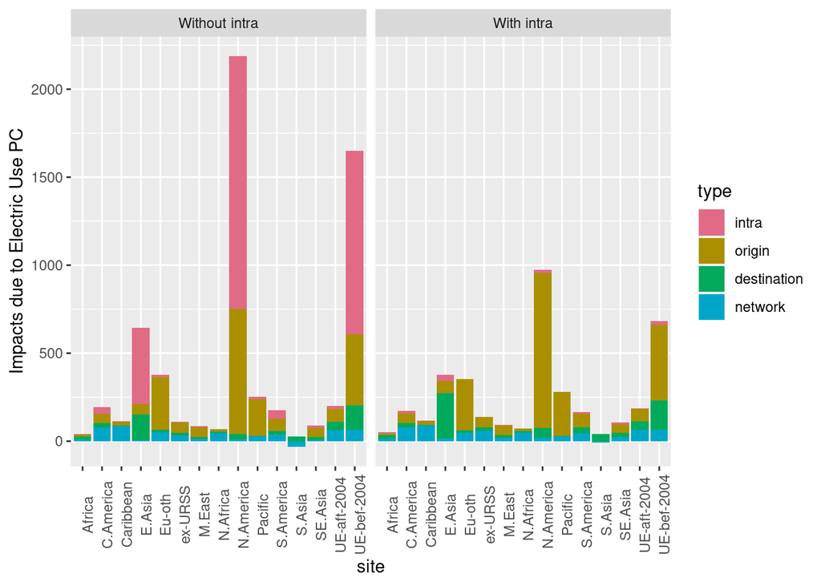

```r
local_effect_elec %>%
  filter(type != "total") %>%
  ggplot() +
  geom_col(aes(x = site, fill = type, y = `Impacts due to Electric Use PC`)) +
  scale_fill_manual(values = q4[1:4]) +
  theme(axis.text.x = element_text(angle = 90))  +
  facet_wrap(~ model)
```

```r
ggsave( filename = "./figures/barplot_elec.pdf", width = 12, height = 5)
```

### 4.3.2 Population

- Alternative local summaries

```r
# without intra
local_effect_pop_without_intra <- data.frame(effect_remit_without_intra$log_pop$local_effect)
local_effect_pop_without_intra$site <- row.names(local_effect_pop_without_intra)
local_effect_pop_without_intra <- pivot_longer(local_effect_pop_without_intra, cols = 1:5,
                             names_to = "type",
                             values_to = "Impacts due to Population")
# with intra
local_effect_pop_with_intra <- data.frame(effect_remit_with_intra$log_pop$local_effect)
local_effect_pop_with_intra$site <- row.names(local_effect_pop_with_intra)
local_effect_pop_with_intra <- pivot_longer(local_effect_pop_with_intra, cols = 1:5,
                             names_to = "type",
                             values_to = "Impacts due to Population")
```

- Local plot

```r
# without intra
local_effect_pop_without_intra$type <- factor(local_effect_pop_without_intra$type,
      levels = c("IE", "OE", "DE", "NE", "TE"),
      labels = c("intra", "origin", "destination", "network", "total"))
local_effect_pop_without_intra$model <- "Without intra"
# with intra
local_effect_pop_with_intra$type <- factor(local_effect_pop_with_intra$type,
      levels = c("IE", "OE", "DE", "NE", "TE"),
      labels = c("intra", "origin", "destination", "network", "total"))
local_effect_pop_with_intra$model <- "With intra"

local_effect_pop<- rbind(local_effect_pop_without_intra, local_effect_pop_with_intra)

local_effect_pop$model <- factor(local_effect_pop$model, levels = c("Without intra", "With intra"))
```

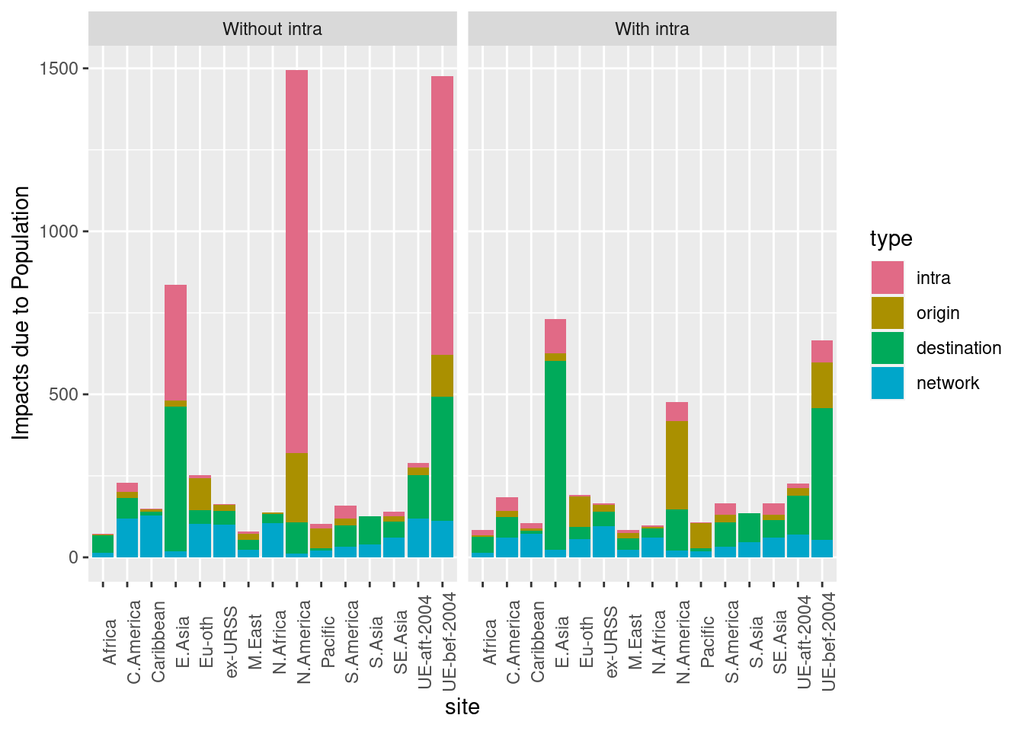

```r
local_effect_pop %>%
  filter(type != "total") %>%
  ggplot() +
  geom_col(aes(x = site, fill = type, y = `Impacts due to Population`)) +
  scale_fill_manual(values = q4[1:4]) +
  theme(axis.text.x = element_text(angle = 90))  +
  facet_wrap(~ model)
```

```r
# ggsave( filename = "./figures/barplot_population.pdf", width = 12, height = 5)
```

### 4.3.3 Transfer cost

- Alternative local summaries

```r
# without intra
local_effect_WU_resid_without_intra <- data.frame(effect_remit_without_intra$WU_resid$local_effect)
local_effect_WU_resid_without_intra$site <- row.names(local_effect_WU_resid_without_intra)
local_effect_WU_resid_without_intra <- pivot_longer(local_effect_WU_resid_without_intra, cols = 1:5,
                             names_to = "type",
                             values_to = "Impacts due to Transfer Cost")
# with intra
local_effect_WU_resid_with_intra <- data.frame(effect_remit_with_intra$WU_resid$local_effect)
local_effect_WU_resid_with_intra$site <- row.names(local_effect_WU_resid_with_intra)
local_effect_WU_resid_with_intra <- pivot_longer(local_effect_WU_resid_with_intra, cols = 1:5,
                             names_to = "type",
                             values_to = "Impacts due to Transfer Cost")
```

- Local plot

```r
# without intra
local_effect_WU_resid_without_intra$type <- factor(local_effect_WU_resid_without_intra$type,
      levels = c("IE", "OE", "DE", "NE", "TE"),
      labels = c("intra", "origin", "destination", "network", "total"))
local_effect_WU_resid_without_intra$model <- "Without intra"
# with intra
local_effect_WU_resid_with_intra$type <- factor(local_effect_WU_resid_with_intra$type,
      levels = c("IE", "OE", "DE", "NE", "TE"),
      labels = c("intra", "origin", "destination", "network", "total"))
local_effect_WU_resid_with_intra$model <- "With intra"

local_effect_WU_resid <- rbind(local_effect_WU_resid_without_intra, local_effect_WU_resid_with_intra)

local_effect_WU_resid$model <- factor(local_effect_WU_resid$model, levels = c("Without intra", "With intra"))
```

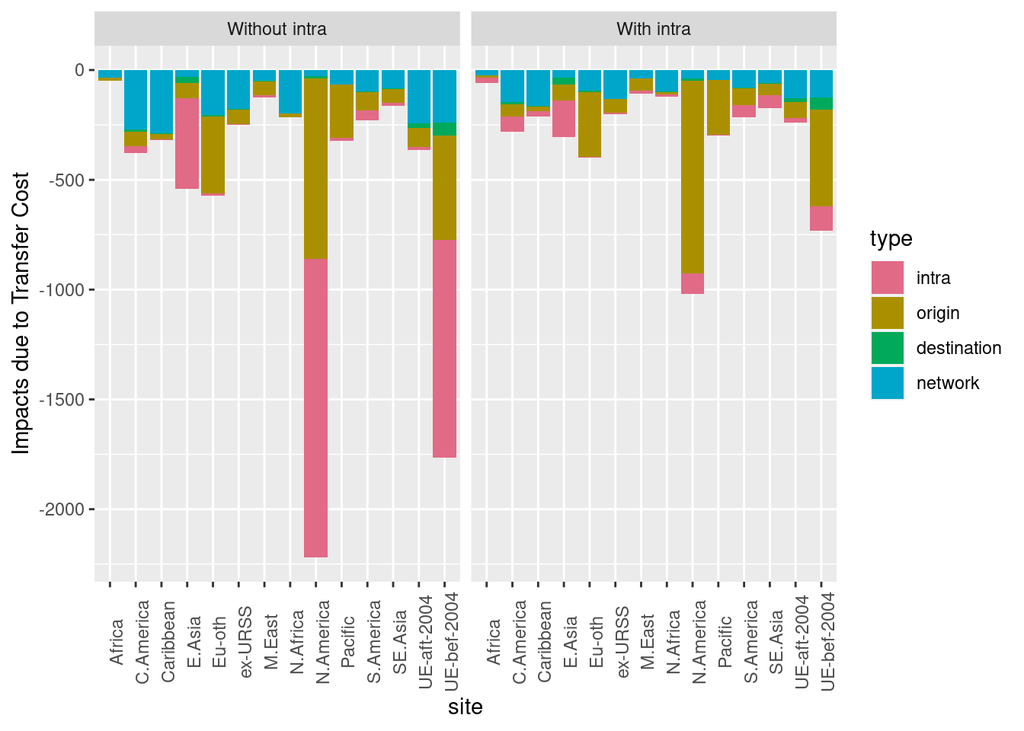

```r
local_effect_WU_resid %>%
  filter(type != "total") %>%
  ggplot() +
  geom_col(aes(x = site, fill = type, y = `Impacts due to Transfer Cost`)) +
  scale_fill_manual(values = q4[1:4]) +
  theme(axis.text.x = element_text(angle = 90))  +
  facet_wrap(~ model)
```

```r
# ggsave( filename = "./figures/barplot_transfer.pdf", width = 12, height = 5)
```

### 4.3.4 Political Stability

- Alternative local summaries

```r
# without intra
local_effect_polstab_without_intra <- data.frame(effect_remit_without_intra$polstab$local_effect)
local_effect_polstab_without_intra$site <- row.names(local_effect_polstab_without_intra)
local_effect_polstab_without_intra <- pivot_longer(local_effect_polstab_without_intra, cols = 1:5,
                             names_to = "type",
                             values_to = "Impacts due to Political stability")
# with intra
local_effect_polstab_with_intra <- data.frame(effect_remit_with_intra$polstab$local_effect)
local_effect_polstab_with_intra$site <- row.names(local_effect_polstab_with_intra)
local_effect_polstab_with_intra <- pivot_longer(local_effect_polstab_with_intra, cols = 1:5,
                             names_to = "type",
                             values_to = "Impacts due to Political stability")
```

- Local plot

```r
# without intra
local_effect_polstab_without_intra$type <- factor(local_effect_polstab_without_intra$type,
      levels = c("IE", "OE", "DE", "NE", "TE"),
      labels = c("intra", "origin", "destination", "network", "total"))
local_effect_polstab_without_intra$model <- "Without intra"
# with intra
local_effect_polstab_with_intra$type <- factor(local_effect_polstab_with_intra$type,
      levels = c("IE", "OE", "DE", "NE", "TE"),
      labels = c("intra", "origin", "destination", "network", "total"))
local_effect_polstab_with_intra$model <- "With intra"

local_effect_polstab <- rbind(local_effect_polstab_without_intra, local_effect_polstab_with_intra)

local_effect_polstab$model <- factor(local_effect_polstab$model, levels = c("Without intra", "With intra"))
```

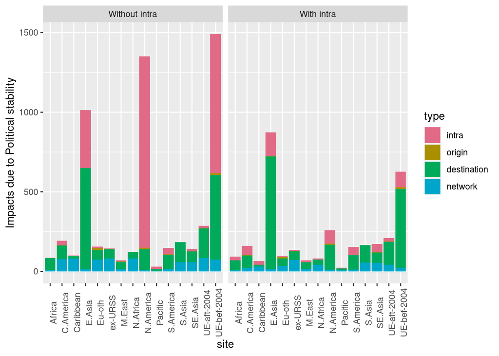

```r
local_effect_polstab %>%
  filter(type != "total") %>%
  ggplot() +
  geom_col(aes(x = site, fill = type, y = `Impacts due to Political stability`)) +
  scale_fill_manual(values = q4[1:4]) +
  theme(axis.text.x = element_text(angle = 90))  +
  facet_wrap(~ model)
```

```r
ggsave( filename = "./figures/barplot_political.pdf", width = 12, height = 5)
```

# 5 Second case study

The results of this case study are not exhibited in the article. Its purpose is to illustrate the impact decomposition on a larger size.

We import the data from the `spflow` package:

```r
library(spflow)
library(sf)
data("paris10km_commuteflows")
data("paris10km_municipalities")

# create the vector of flows
index_o <- paris10km_commuteflows$ID_ORIG
index_d <- paris10km_commuteflows$ID_DEST
y <- paris10km_commuteflows[, "COMMUTE_FLOW"]
# create the spatial objects with the polygons of the site
contours_map <- paris10km_municipalities # [paris_intra_S, ]
# change the centroid of one polygon
xy_sf <- st_centroid(contours_map)
st_geometry(xy_sf[xy_sf$ID_MUN== "93039", ]) <-
  st_geometry(xy_sf[xy_sf$ID_MUN== "93039", ]) + c(0.012, 0)
```

We plot the map:

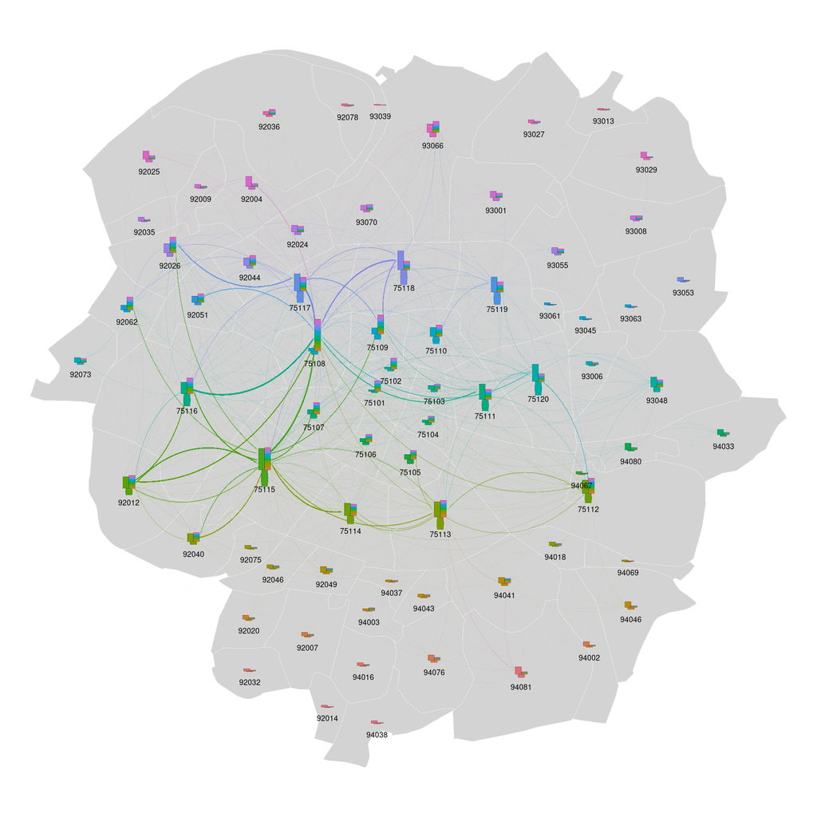

```r
# pdf("paris.pdf", width = 7, height = 7)
par(oma = c(0, 0, 0, 0), mar = c(0, 0, 0, 0))
plot_flows(
    y, # value of the flow
    index_o, # label of the origin
    index_d,  # label of the destination
    geo_site = contours_map,  # the geographic coordinates of the sites: polygon or points of class sf
    column_name = "ID_MUN", # the column name of the regions in geo_site sf object and/or in xy_sf
     add = F,   # if add = T, the arcs and only the arcs will printed on the existing device
    type = "barchart", # if T plot barplot for outloflows/inflows and intra flows
    xy_sf= xy_sf,
    transparency = list(alpha = c(0.01, 0.2, 1),
                        range = c(0, 2000, 3000)), # a scalar between 0 and 1 : 0 is huge transpareny and 1 is no transparency
    width_arc = 3, # width of the arc that is also equals to the height of the bar
    size_head_arc = 0.5, # the size of the ending and starting of the arrows
    reduce_arc = 0.05, # the percentage of reduction of the flow
    percent_arc = 1, # the percentage of flows to represent
    width_bar = 0.8, # the width of the barplot
    lwd_bar = 0.1,   # the lwd of the bar
    percent_bar = 1, # the percentage of barplot to print
    col_direction = "outflows", # a character among "outflows", "inflows", "none"; by default, the outflows will be plotted in color
    col_geometry = "lightgrey",  # color inside the polygons
    border_geometry = "white", # color of the contours
    lwd_geometry = 0.2, # width of the contours
    print_names = T,
    size_names = 0.5
)
```

```r
# dev.off()
```

We generate the explanatory variables

```r
n_paris <- nrow(paris10km_municipalities)
X <- st_drop_geometry(paris10km_municipalities[,
      c("POPULATION", "NB_COMPANY", "MED_INCOME")])
row.names(X) <- paris10km_municipalities$ID_MUN
```

We compute the spatial weight matrix

```r
library(spdep)
mat_paris <- listw2mat(nb2listw(knn2nb(knearneigh(
  st_coordinates(st_centroid(paris10km_municipalities)),
  k = 4))))
names_paris <- paris10km_municipalities$ID_MUN
row.names(mat_paris) <- colnames(mat_paris) <- names_paris
```

```r
W_o_paris <- kronecker(mat_paris, diag(n_paris))
flow_names <- paste0(rep(names_paris, each = n_paris), "-",
                     rep(names_paris, times = n_paris))
dimnames(W_o_paris) <- list(flow_names, flow_names)
W_d_paris <- kronecker(diag(n_paris), mat_paris)
dimnames(W_d_paris) <- list(flow_names, flow_names)
```

Estimation

```r
source("codes/ftrace1.R")
source("codes/sar_flow_2.R")
```

We select the OD pairs in the same order than the spatial weight matrices:

```r
row.names(paris10km_commuteflows) <- paste0(
  paris10km_commuteflows$ID_ORIG, "-", paris10km_commuteflows$ID_DEST
)
index_o <- paris10km_commuteflows[flow_names, "ID_ORIG"]
index_d <- paris10km_commuteflows[flow_names, "ID_DEST"]
y <- paris10km_commuteflows[flow_names, "COMMUTE_FLOW"]
pairs_od <- paris10km_commuteflows[flow_names, "DISTANCE"]
```

```r
my_data_c <- data.frame(
  cst_intra = ifelse(index_o == index_d, 1, 0),

  log_pop_o = log(X[index_o, "POPULATION"]),
  log_intra_pop = ifelse(index_o == index_d,
      log(X[index_o, "POPULATION"]), 0),
  lagged_log_pop_o = W_o_paris %*% log(X[index_o, "POPULATION"]),

  log_company_d = log(X[index_d, "NB_COMPANY"]),
  lagged_log_company_d = W_d_paris %*% log(X[index_d, "POPULATION"]),

  log_income_o = log(X[index_o, "MED_INCOME"]),
  log_income_d = log(X[index_d, "MED_INCOME"]),
  lagged_income_o = W_o_paris %*% log(X[index_o, "MED_INCOME"]),
  lagged_income_d = W_d_paris %*% log(X[index_d, "MED_INCOME"])
  )
```

```r
library("Matrix")
sdm_bay_with_intra <- sar_flow_2(
  x = my_data_c,
  y = log(1 + y),
  g = log(1 + pairs_od),
  W_o = W_o_paris, W_d = W_d_paris,
  model = "model_7",
  ndraw = 2000L, nomit = 1000L)
save(sdm_bay_with_intra, file = "res_paris.RData")
```

```r
load("res_paris.RData")
sdm_bay_sum_with_intra <- summary_bayesian_sar_flow(sdm_bay_with_intra)
```

```
##              mean      median   lower_05      lower_95      t_stat
##  [1,]  0.12223448  0.12230993  0.1024908  0.1425729661  10.0588745
##  [2,]  0.65491126  0.65552907  0.6382583  0.6711876096  65.6072662
##  [3,]  1.03011099  1.03321654 -0.1369677  2.1983226088   1.3910291
##  [4,]  6.81411020  6.83128846  4.8110827  8.7469920458   5.8351033
##  [5,]  0.85792924  0.85808503  0.8301127  0.8863317321  49.9556203
##  [6,] -0.50201212 -0.50294484 -0.6814523 -0.3260351277  -4.7023264
##  [7,] -0.64054762 -0.64088851 -0.6905261 -0.5896242163 -20.3273347
##  [8,]  0.31199315  0.31218380  0.2890571  0.3340349616  22.8332915
##  [9,] -0.23600051 -0.23400259 -0.2912205 -0.1835846945  -7.1193262
## [10,] -0.10432935 -0.10481517 -0.2087636 -0.0007885092  -1.6620151
## [11,] -0.32756854 -0.32835035 -0.4318088 -0.2226691267  -5.1802332
## [12,] -0.06684672 -0.06715939 -0.1959744  0.0702782010  -0.8273421
## [13,]  0.41555525  0.41598540  0.2759281  0.5536890774   4.8962897
## [14,] -0.19371523 -0.19373803 -0.2324932 -0.1554288405  -8.1179351
```

```r
# with intra
rho_remit_with_intra <- c(sdm_bay_sum_with_intra[1:2, 1], 0)
alpha_remit_with_intra <- sdm_bay_sum_with_intra[3, 1]
coeff_remit_with_intra <- data.frame(
  row.names = c("POPULATION", "NB_COMPANY", "MED_INCOME"),
  beta_o = c(sdm_bay_sum_with_intra[5, 1], 0, sdm_bay_sum_with_intra[10, 1]),
  beta_d = c(0, sdm_bay_sum_with_intra[c(8, 11), 1]),
  delta_o = c(sdm_bay_sum_with_intra[7, 1], 0, sdm_bay_sum_with_intra[12, 1]),
  delta_d = c(0, sdm_bay_sum_with_intra[c(9, 13), 1]),
  beta_i = c(sdm_bay_sum_with_intra[6, 1], 0, 0))
```

To obtain the predictions, we need to compute the part containing the variable characterizing the OD pairs:

```r
omega_vec_remit_with_intra <- my_data_c$cst_intra * sdm_bay_sum_with_intra[4, 1] +
  log(1 + pairs_od) * sdm_bay_sum_with_intra[14, 1]
```

We compute the predictions as the model is in log:

```r
source("codes/predict_cartesian.R")
source("codes/predict_non_cartesian.R")
```

```r
tc_remit_with_intra <- as.vector(
  predict_gsim(coeff_remit_with_intra, rho_remit_with_intra,
               alpha = alpha_remit_with_intra,
               omega_vec = omega_vec_remit_with_intra, # cste,
               OW = mat_paris, DW = mat_paris,
               OX = log(X), DX = log(X),
               ind_o = index_o,
               ind_d = index_d))
```

Then, we implement the impact decomposition:

```r
source("codes/compute_effects_cartesian.R")
source("codes/compute_effects_non_cartesian.R")
```

```r
effect_remit_with_intra <- compute_effect(coeff_remit_with_intra,
                            rho_remit_with_intra,
                            OW = mat_paris, DW = mat_paris,
                            ind_o = index_o, ind_d = index_d,
                            site = "all", Y_in_log = T,
                            hat_y = exp(tc_remit_with_intra),
                            change_z = c(0.01, 0.01, 0.01))
```

Global summary measures:

```r
res_2 <- round(t(sapply(effect_remit_with_intra, function(x) apply(x$local_effect, 2, sum))) / n_paris ^ 2, 1)
res_2
```

```
##               IE    OE    DE     NE    TE
## POPULATION  77.7 150.5  -4.3 -149.8  74.1
## NB_COMPANY  14.9   0.0  22.2   -1.4  35.7
## MED_INCOME -27.0 -18.8 -20.9   27.9 -38.8
```

Population:

- Alternative local summaries

```r
library(tidyr)
local_effect_POPULATION_with_intra <- data.frame(effect_remit_with_intra$POPULATION$local_effect)
local_effect_POPULATION_with_intra$site <- row.names(local_effect_POPULATION_with_intra)
local_effect_POPULATION_with_intra <- pivot_longer(local_effect_POPULATION_with_intra, cols = 1:5,
                             names_to = "type",
                             values_to = "Impacts due to Population")
```

- Local plot

```r
# with intra
local_effect_POPULATION_with_intra$type <- factor(local_effect_POPULATION_with_intra$type,
      levels = c("IE", "OE", "DE", "NE", "TE"),
      labels = c("intra", "origin", "destination", "network", "total"))
local_effect_POPULATION_with_intra$model <- "With intra"
```

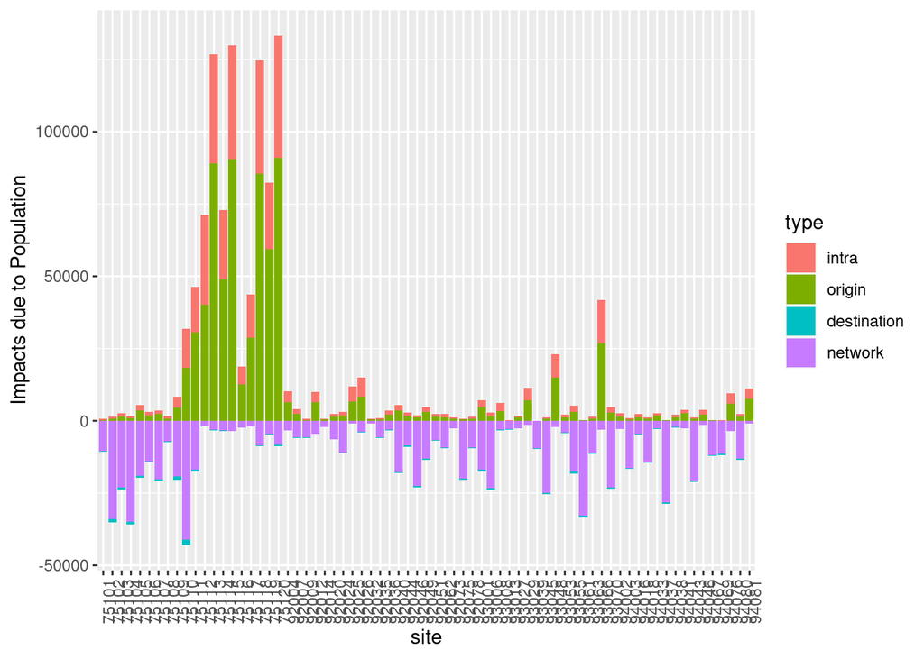

```r
library(tidyverse)
local_effect_POPULATION_with_intra %>%
  filter(type != "total") %>%
  ggplot() +
  geom_col(aes(x = site, fill = type, y = `Impacts due to Population`)) +
  theme(axis.text.x = element_text(angle = 90))
```

Number of Companies:

- Alternative local summaries

```r
library(tidyr)
local_effect_Company_with_intra <- data.frame(effect_remit_with_intra$NB_COMPANY$local_effect)
local_effect_Company_with_intra$site <- row.names(local_effect_Company_with_intra)
local_effect_Company_with_intra <- pivot_longer(local_effect_Company_with_intra,
                                                cols = 1:5,
                             names_to = "type",
                             values_to = "Impacts due to Companies")
```

- Local plot

```r
# with intra
local_effect_Company_with_intra$type <- factor(local_effect_Company_with_intra$type,
      levels = c("IE", "OE", "DE", "NE", "TE"),
      labels = c("intra", "origin", "destination", "network", "total"))
local_effect_Company_with_intra$model <- "With intra"
```

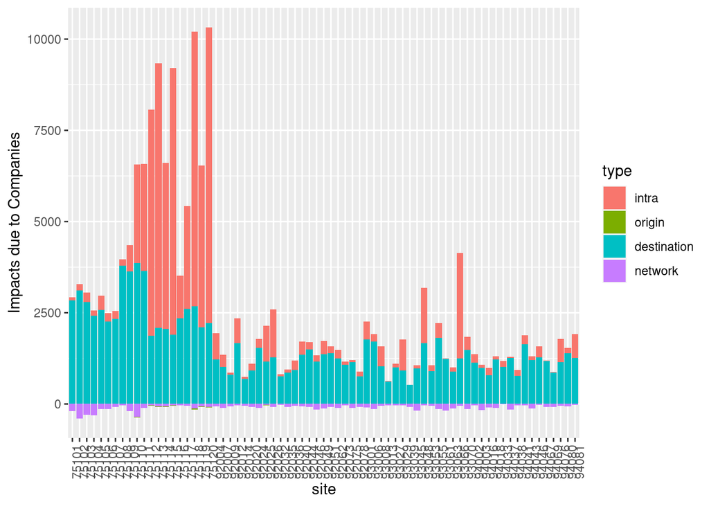

```r
library(tidyverse)
local_effect_Company_with_intra %>%
  filter(type != "total") %>%
  ggplot() +
  geom_col(aes(x = site, fill = type, y = `Impacts due to Companies`)) +
  theme(axis.text.x = element_text(angle = 90))
```

Income:

- Alternative local summaries

```r
library(tidyr)
local_effect_income_with_intra <- data.frame(effect_remit_with_intra$MED_INCOME$local_effect)
local_effect_income_with_intra$site <- row.names(local_effect_income_with_intra)
local_effect_income_with_intra <- pivot_longer(local_effect_income_with_intra,
                                               cols = 1:5,
                             names_to = "type",
                             values_to = "Impacts due to Income")
```

- Local plot

```r
# with intra
local_effect_income_with_intra$type <- factor(local_effect_income_with_intra$type,
      levels = c("IE", "OE", "DE", "NE", "TE"),
      labels = c("intra", "origin", "destination", "network", "total"))
local_effect_income_with_intra$model <- "With intra"
```

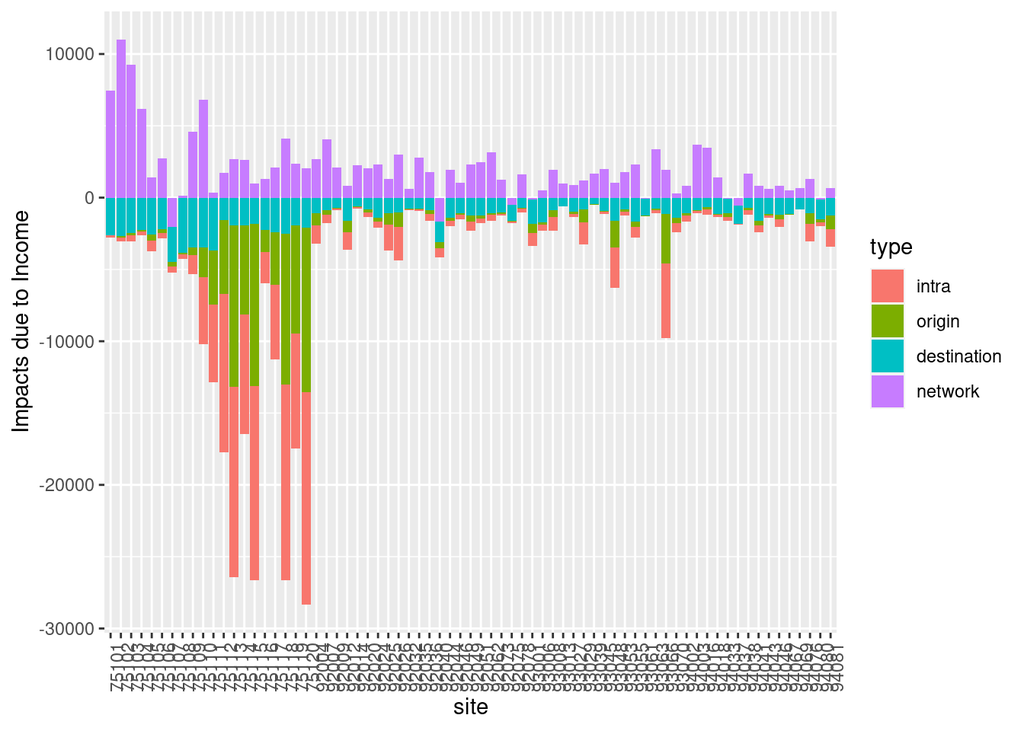

```r
library(tidyverse)
local_effect_income_with_intra %>%
  filter(type != "total") %>%
  ggplot() +
  geom_col(aes(x = site, fill = type, y = `Impacts due to Income`)) +
  theme(axis.text.x = element_text(angle = 90))
```